# Capstone Project: Create a Customer Segmentation Report for Arvato Financial Services

In this project, you will analyze demographics data for customers of a mail-order sales company in Germany, comparing it against demographics information for the general population. You'll use unsupervised learning techniques to perform customer segmentation, identifying the parts of the population that best describe the core customer base of the company. Then, you'll apply what you've learned on a third dataset with demographics information for targets of a marketing campaign for the company, and use a model to predict which individuals are most likely to convert into becoming customers for the company. The data that you will use has been provided by our partners at Bertelsmann Arvato Analytics, and represents a real-life data science task.

If you completed the first term of this program, you will be familiar with the first part of this project, from the unsupervised learning project. The versions of those two datasets used in this project will include many more features and has not been pre-cleaned. You are also free to choose whatever approach you'd like to analyzing the data rather than follow pre-determined steps. In your work on this project, make sure that you carefully document your steps and decisions, since your main deliverable for this project will be a blog post reporting your findings.

```python
# import libraries
import numpy as np
import pandas as pd
import matplotlib.pyplot as plt
import seaborn as sns

# sklearn libraries for ML modelling
from sklearn.pipeline import Pipeline
from sklearn.model_selection import train_test_split, StratifiedKFold, StratifiedShuffleSplit, learning_curve
from sklearn.model_selection import GridSearchCV, RandomizedSearchCV
from sklearn.impute import SimpleImputer
from sklearn.preprocessing import StandardScaler
from sklearn.neural_network import MLPClassifier
from sklearn.ensemble import AdaBoostClassifier, GradientBoostingClassifier, ExtraTreesClassifier
from sklearn.metrics import roc_curve, roc_auc_score, classification_report

# magic word for producing visualizations in notebook
%matplotlib inline
```

```python
# configure seaborn style
sns.set_style('darkgrid')
sns.set_context('paper', font_scale=1.4)

# set custom seaborn palette
colors = ['#4E79A7', '#F28E2B', '#E15759', '#76B7B2', '#59A14F',
          '#EDC948', '#B07AA1', '#FF9DA7', '#9C755F', '#BAB0AC']

# set default color palette
tableau10 = sns.color_palette(colors)
sns.set_palette(tableau10)
```

## Part 1: Get to Know the Data

Each row of the demographics files represents a single person, but also includes information outside of individuals, including information about their household, building, and neighborhood. Use the information from the first two files to figure out how customers ("CUSTOMERS") are similar to or differ from the general population at large ("AZDIAS"), then use your analysis to make predictions on the other two files ("MAILOUT"), predicting which recipients are most likely to become a customer for the mail-order company.

The "CUSTOMERS" file contains three extra columns ('CUSTOMER_GROUP', 'ONLINE_PURCHASE', and 'PRODUCT_GROUP'), which provide broad information about the customers depicted in the file. The original "MAILOUT" file included one additional column, "RESPONSE", which indicated whether or not each recipient became a customer of the company. For the "TRAIN" subset, this column has been retained, but in the "TEST" subset it has been removed; it is against that withheld column that your final predictions will be assessed in the Kaggle competition.

Otherwise, all of the remaining columns are the same between the three data files. For more information about the columns depicted in the files, you can refer to two Excel spreadsheets provided in the workspace. One of them is a top-level list of attributes and descriptions, organized by informational category. The other is a detailed mapping of data values for each feature in alphabetical order.

In the below cell, we've provided some initial code to load in the first two datasets. Note for all of the `.csv` data files in this project that they're semicolon (`;`) delimited, so an additional argument in the [`read_csv()`](https://pandas.pydata.org/pandas-docs/stable/generated/pandas.read_csv.html) call has been included to read in the data properly. Also, considering the size of the datasets, it may take some time for them to load completely.

You'll notice when the data is loaded in that a warning message will immediately pop up. Before you really start digging into the modeling and analysis, you're going to need to perform some cleaning. Take some time to browse the structure of the data and look over the informational spreadsheets to understand the data values. Make some decisions on which features to keep, which features to drop, and if any revisions need to be made on data formats. It'll be a good idea to create a function with pre-processing steps, since you'll need to clean all of the datasets before you work with them.

```python
# load in the population data (local workspace)
azdias = pd.read_csv('./arvato_data/Udacity_AZDIAS_052018.csv', sep=';', low_memory=False)
```

```python
# get information on data
azdias.info()
```

```
<class 'pandas.core.frame.DataFrame'>
RangeIndex: 891221 entries, 0 to 891220
Columns: 366 entries, LNR to ALTERSKATEGORIE_GROB
dtypes: float64(267), int64(93), object(6)
memory usage: 2.4+ GB
```

```python
# get number of total and missing entries
missing_entries = azdias.isnull().sum().sum()
total_entries = azdias.shape[0]*azdias.shape[1]
print("total entries: {:}".format(total_entries))
print("missing entries: {:}".format(missing_entries))
print("percentage: {:.1f}%".format(missing_entries/total_entries*100.0))
```

```
total entries: 326186886
missing entries: 33492923
percentage: 10.3%
```

**Observations**

- population dataset has 891221 entries (=rows), 366 features (=columns)
- from the features 267 are numerical, 93 are integer, 6 object are (string) features
- before encoding unknown and missing values properly, 10% of the data is missing

### 1.2 Handle unknown values and analzye missing data

The dataset of the general population consists of **891221 entries (=rows)** and **366 features (=columns)**. In total around **10% of the entries are missing**, however, there are still unknown entries in the dataset. To identify the codes for unknown entries, the supporting description files were **manually scanned**, and missing values and undescribed features were documented in a new table: *feature_info.csv*.

```python
# load feature_info.csv
feat_info = pd.read_csv('feature_info.csv', delimiter=';')
# drop first row
feat_info.drop(0, axis=0, inplace=True)
# drop # column as it is identical with the index
feat_info.drop(['#'], axis=1, inplace=True)

feat_info.head(5)
```

|  | FEATURE | TYPE | UNKNOWN | DESCRIBED | COMMENT | DECISION |
| --- | --- | --- | --- | --- | --- | --- |
| 1 | LNR | numerical | [] | 0 | probably laufende nummer = id; can be disgarded | drop |
| 2 | AGER_TYP | categorical | [-1] | 1 | NaN | one-hot encode |
| 3 | AKT_DAT_KL | categorical | [] | 0 | no infromation availabe on codes; | investigate |
| 4 | ALTER_HH | ordinal | [0] | 1 | NaN | keep |
| 5 | ALTER_KIND1 | numerical | [] | 0 | age of first kid; could be included | maybe include |

```python
# get missing/unknown codes from feat_info data frame
# get list of strings by removing brackets and splitting at commas
missing_list_str = list(feat_info['UNKNOWN'].apply(lambda x: x.replace('[', '').replace(']', '').split(',')))

# convert lists of missing strings to lists of missing numbers
missing_list = []
for i in range(len(missing_list_str)):
    # if no missing/unknown code, provide empty list
    if '' in missing_list_str[i]:
        missing_list.append([])
    # else convert strings with digits to numbers and leave strings without digits unchanged
    else:
        missing_list.append([int(val) if val.lstrip('-').isdigit() else val for val in missing_list_str[i]])

# missing_list contains the missing/unknown codes for each column
print(len(missing_list))
print(missing_list)
```

```
366
[[], [-1], [], [0], [], [], [], [], [-1, 0], [], [], [], [], [], [], [9], [-1], ['XX', -1], ['X', -1], ['XX', -1], [0], [], [], [], [], [], [], [], [], [], [], [], [], [], [], [], [], [], [], [], [], [], [], [], [], [], [], [], [], [], [], [], [], [], [], [], [], [], [], [], [], ['D19_UNBEKANNT'], […
```

```python
# get features of type object
azdias.select_dtypes(include=['object']).columns
```

```
Index(['CAMEO_DEU_2015', 'CAMEO_DEUG_2015', 'CAMEO_INTL_2015',
       'D19_LETZTER_KAUF_BRANCHE', 'EINGEFUEGT_AM', 'OST_WEST_KZ'],
      dtype='object')
```

**Observations**

- there are 6 features encoded as string (object) type
- in the list of missing/unknown codes, 4 entries are strings
- the remaining 2 object features are `EINGEFUEGT_AM` and `OST_WEST_KZ`
  - `OST_WEST_KZ` missing entries are aleady encoded as NaN
  - `EINGEFUEGT_AM` relates to the date when the entry was added; it is not relevant for the cluster analysis

```python
# convert missing or unknown data values to NaNs.

# create copy of data to leave original data frame unchanged
azdias_replaced = azdias.copy()

# loop over columns and replace missing/unknown data skipping columns without missing/unknown codes
for i, col in enumerate(azdias_replaced.columns):
    if missing_list[i] != []:
        azdias_replaced[col] = azdias[col].replace(missing_list[i], np.NaN)
```

```python
# re-assess quantity of data after replacing missing and unknown values
replaced_entries = azdias_replaced.isnull().sum().sum() - missing_entries

print('total values: %i' % total_entries)
print('initially missing values: %i' % missing_entries)
print('values replaced: %i' % replaced_entries)
print('total missing values: %i' % (missing_entries + replaced_entries))
print('final fraction missing: %.2f%%' % ((missing_entries + replaced_entries)/total_entries*100.0))
```

```
total values: 326186886
initially missing values: 33492923
values replaced: 5749687
total missing values: 39242610
final fraction missing: 12.03%
```

```python
# check for example if 'D19_UNBEKANNT' has been replaced
azdias_replaced['D19_LETZTER_KAUF_BRANCHE'].value_counts()
```

```
D19_VERSICHERUNGEN        57734
D19_SONSTIGE              44722
D19_VOLLSORTIMENT         34812
D19_SCHUHE                32578
D19_BUCH_CD               28754
D19_VERSAND_REST          26034
D19_DROGERIEARTIKEL       24072
D19_BANKEN_DIREKT         23273
D19_BEKLEIDUNG_REST       21796
D19_HAUS_DEKO             20858
D19_TELKO_MOBILE          14447
D19_ENERGIE               12084
D19_TELKO_REST            11472
D19_BANKEN_GROSS          10550
D19_BEKLEIDUNG_GEH        10272
D19_KINDERARTIKEL          7301
D19_FREIZEIT               7257
D19_TECHNIK                7002
D19_LEBENSMITTEL           6458
D19_BANKEN_REST            5247
D19_RATGEBER               4931
D19_NAHRUNGSERGAENZUNG     4061
D19_DIGIT_SERV             3577
D19_REISEN                 3122
D19_TIERARTIKEL            2578
D19_SAMMELARTIKEL          2443
D19_HANDWERK               2227
D19_WEIN_FEINKOST          2164
D19_GARTEN                 1646
D19_BANKEN_LOKAL           1442
D19_BIO_OEKO               1232
D19_BILDUNG                 980
D19_LOTTO                   839
D19_KOSMETIK                805
Name: D19_LETZTER_KAUF_BRANCHE, dtype: int64
```

### 1.3 Analyze distribution of missing data in columns

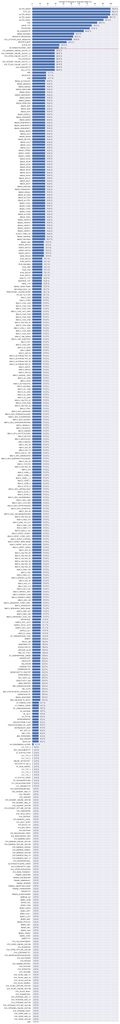

```python
# assess how much missing data there is in each column of the dataset.

# total rows
n_entries = azdias.shape[0]

# missing data per column after replacing missing and unknown values
missing_after_cleaning = n_entries - azdias_replaced.count()

# fraction of missing data
fraction_missing = missing_after_cleaning/n_entries

# sort missing data fraction in descending order
idx = np.argsort(fraction_missing)

# visiualize missing data in barplot
sns.set()
plt.figure(figsize=(10,120))
plt.barh(range(1,azdias_replaced.shape[1]+1), fraction_missing[idx]*100.0,
         height=0.8, tick_label=azdias_replaced.columns[idx])
plt.hlines(351.5, xmin=0.0, xmax=110.0, colors='r', linestyles='--')
plt.xticks(np.linspace(0,100,11))
plt.xlim(0.0, 110.0)
plt.ylim(1, azdias.shape[1]+1)
plt.xlabel('fraction of missing or unknown data (%)')
ax = plt.gca()
ax.xaxis.tick_top()
ax.xaxis.set_label_position('top')
# add values to the bars
for i, val in enumerate(fraction_missing[idx]):
    plt.text(val*100.0+2.0, i+0.75, '%.1f %%' % (val*100))
```

**Observations**

- in 12 columns more than 50% of the values are missing or unknown:
  - `ALTER_KIND4`, `TITEL_KZ`, `ALTER_KIND3`, `ALTER_KIND2`, `ALTER_KIND1`, `VHA`, `AGER_TYP`, `EXTSEL992`, `KK_KUNDENTYP`, `KBA05_BAUMAX`, `VERDICHTUNGSRAUM`, `D19_LETZTER_KAUF_BRANCHE`
  - these columns will be dropped from the dataset as imputation is not reliable at high fractions of missing values
- in 3 more columns more than 30% of the values are missing:
  - `GEBURTSJAHR`, `ALTER_HH`, `ALTERSKATEGORIE_FEIN`
  - these columns will also be dropped, as a more coarse-grained category (`ALTERSKATEGORIE_GROB`) is available in the dataset

```python
# drop columns with high fraction of missing data
column_missing_threshold = 0.3

drop_columns = list(azdias_replaced.columns[fraction_missing >= column_missing_threshold])
print(drop_columns)

azdias_cleaned = azdias_replaced.drop(drop_columns, axis=1)
print(azdias_cleaned.shape)
```

```
['AGER_TYP', 'ALTER_HH', 'ALTER_KIND1', 'ALTER_KIND2', 'ALTER_KIND3', 'ALTER_KIND4', 'ALTERSKATEGORIE_FEIN', 'D19_LETZTER_KAUF_BRANCHE', 'EXTSEL992', 'GEBURTSJAHR', 'KBA05_BAUMAX', 'KK_KUNDENTYP', 'TITEL_KZ', 'VERDICHTUNGSRAUM', 'VHA']
(891221, 351)
```

```python
# remove dropped columns also from feat_info dataframe
feat_info = feat_info[~feat_info['FEATURE'].isin(drop_columns)]
```

```python
# also drop other features that were identified during the analysis of the features
# (e.g. date when the entry was added to the database, or features without clear description)
print(feat_info[feat_info['DECISION'] == 'drop'])

drop_columns = ['LNR', 'EINGEFUEGT_AM', 'GEMEINDETYP', 'HH_DELTA_FLAG', 'VHN']

azdias_cleaned.drop(drop_columns, axis=1, inplace=True)
print(azdias_cleaned.shape)

# remove dropped columns also from feat_info dataframe
feat_info = feat_info[~feat_info['FEATURE'].isin(drop_columns)]
```

```
               FEATURE         TYPE UNKNOWN  DESCRIBED  \
1                  LNR    numerical      []          0
58       D19_KONSUMTYP  categorical      []          1
59   D19_KONSUMTYP_MAX  categorical      []          0
98       EINGEFUEGT_AM         date      []          0
113        GEMEINDETYP  categorical      []          0
117      HH_DELTA_FLAG       binary      []          0
307    LP_FAMILIE_GROB  categorical     [0]          1
310     LP_STATUS_FEIN      ordinal      []          1
357                VHN      ordinal     [0]          0

                                               COMMENT DECISION
1      probably laufende nummer = id; can be disgarded     drop
58                                   many missing data     drop
59   probably most frequent KONSUMTYP in cell; cont...     drop
98   probably when entry was added to dataset (not ...     drop
113  no infromation availabe on codes; could be inc...     drop
117                          no information on meaning     drop
307  not needed as more detailed information is ava...     drop
310                      very fine-grained information     drop
357  no information, probably 0 for missing; lots o...     drop
(891221, 346)
```

### 1.4 Analyze distribution of missing data in rows

```
  0-4   missing values: 60.2%
  5-9   missing values: 78.4%
 10-14  missing values: 80.7%
 15-19  missing values: 82.2%
 20-24  missing values: 82.6%
 25-29  missing values: 82.7%
 30-34  missing values: 82.7%
 35-39  missing values: 82.7%
 40-44  missing values: 82.7%
 45-49  missing values: 82.7%
 50-54  missing values: 82.7%
 55-59  missing values: 83.4%
 60-64  missing values: 84.6%
 65-69  missing values: 86.6%
 70-74  missing values: 87.8%
 75-79  missing values: 88.0%
 80-84  missing values: 88.1%
 85-89  missing values: 88.1%
 90-94  missing values: 88.1%
 95-99  missing values: 88.1%
100-104 missing values: 88.1%
105-109 missing values: 88.1%
110-114 missing values: 88.1%
115-119 missing values: 88.2%
120-124 missing values: 88.5%
125-129 missing values: 88.5%
130-134 missing values: 88.7%
135-139 missing values: 88.8%
140-144 missing values: 88.8%
145-149 missing values: 88.8%
150-154 missing values: 88.8%
155-159 missing values: 88.8%
160-164 missing values: 88.8%
165-169 missing values: 88.8%
170-174 missing values: 88.8%
175-179 missing values: 88.8%
180-184 missing values: 88.8%
185-189 missing values: 89.3%
190-194 missing values: 89.4%
195-199 missing values: 89.5%
200-204 missing values: 89.5%
205-209 missing values: 89.5%
210-214 missing values: 89.6%
215-219 missing values: 91.2%
220-224 missing values: 91.5%
225-229 missing values: 91.7%
230-234 missing values: 91.7%
235-239 missing values: 91.7%
240-244 missing values: 94.9%
245-249 missing values: 100.0%
```

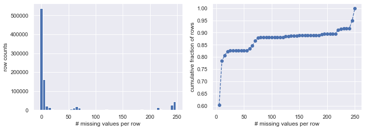

```python
# assess how much data is missing in each row of the dataset and plot results
missing_in_row = azdias_cleaned.isnull().sum(axis=1)

# plot distribution of number of missing values in rows
plt.figure(figsize=(12,4))
plt.subplot(1, 2, 1)
counts, bins, patches = plt.hist(missing_in_row, bins=range(0,255,5), align='left')
plt.xlabel('# missing values per row')
plt.ylabel('row counts')

# plot cumulative distribution
plt.subplot(1, 2, 2)
plt.plot(bins[1:], counts.cumsum()/n_entries, 'o--')
plt.xlabel('# missing values per row')
plt.ylabel('cumulative fraction of rows')

for i in range(bins.size-1):
    print("{:>3d}-{:<3d} missing values: {:.1f}%".format(bins[i], bins[i+1]-1, counts.cumsum()[i]/n_entries*100.0))
#print("fraction:\n", counts.cumsum()/n_entries)
```

# **Observations**

- if all rows with at least one missing value are discarded, only 54% of the data can be used
- by allowing for 5–9 missing values in each row, 78% of the data can be used
  - the missing values need to be imputed in this case
- including rows with an increasing number of missing values, adds only marginally to the amount of data that can be used

```python
# functions to separate rows into complete and incomplete datasets
def separate_rows_missing(data, missing_threshold=0):
    """
    Separate data into a complete and an incomplete dataset based on the missing_threshold of missing values
    in each row.

    Inputs
    ------
    data : dataframe
        data to be split

    missing_threshold : int (optional)
        number of missing values on which the data is split into complete (<=) and incomplete (>)

    Outputs
    -------
    complete_rows : dataframe
        dataset with less or equal than missing_threshold values

    incomplete_rows : dataframe
        dataset with more than missing_threshold values
    """
    # get total number of rows
    n_entries = data.shape[0]

    # get number of missing values per row
    missing_in_row = data.isnull().sum(axis=1)

    # split dataset
    complete_rows = data.loc[missing_in_row <= missing_threshold]
    incomplete_rows = data.loc[missing_in_row > missing_threshold]

    print('# complete row fraction:   {:.1f}%'.format(complete_rows.shape[0]/n_entries*100.0))
    print('# incomplete row fraction: {:.1f}%'.format(incomplete_rows.shape[0]/n_entries*100.0))

    return (complete_rows, incomplete_rows)


# function to plot distributions from complete and incomplete dataset
def plot_feature_distributions(column, complete_data, incomplete_data, plottitle=''):
    """
    Plot distribution of feature (=column) in complete_data and incompelete_data in a single barplot.

    Inputs
    ------
    column : str
        feature name

    complete_data : dataframe
        dataset with less or equal than missing_threshold values

    incomplete_data : dataframe
        dataset with more than missing_threshold values

    Outputs
    -------
    """

    # get number of rows
    n_complete = complete_data.shape[0]
    n_incomplete = incomplete_data.shape[0]
    n_total = n_complete + n_incomplete

    # calculate proportions
    complete_props = complete_data[column].value_counts(normalize=True, sort=False)
    incomplete_props = incomplete_data[column].value_counts(normalize=True)

    # combine into dataframe for plotting
    df_complete = pd.DataFrame(complete_props).reset_index()
    df_complete.columns = ['VALUE', 'PROPORTION']
    df_complete['DATASET'] = 'complete'

    df_incomplete = pd.DataFrame(incomplete_props).reset_index()
    df_incomplete.columns = ['VALUE', 'PROPORTION']
    df_incomplete['DATASET'] = 'incomplete'

    df = pd.concat([df_complete, df_incomplete], axis=0)

    # plot proportions in one barplot
    plt.figure(figsize=(6,4))
    sns.barplot(data=df, x='VALUE', y='PROPORTION', hue='DATASET')
    plt.title(column + ": <=" + plottitle + " missing values")
    plt.tight_layout()

    return plt.gca()
```

```
missing threshold = 0
# complete row fraction:   54.4%
# incomplete row fraction: 45.6%

missing threshold = 4
# complete row fraction:   60.2%
# incomplete row fraction: 39.8%

missing threshold = 9
# complete row fraction:   78.4%
# incomplete row fraction: 21.6%
```

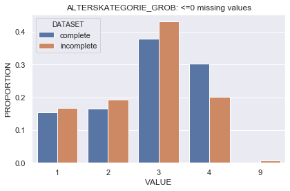

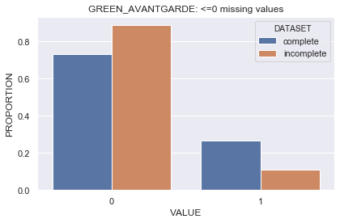

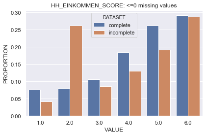

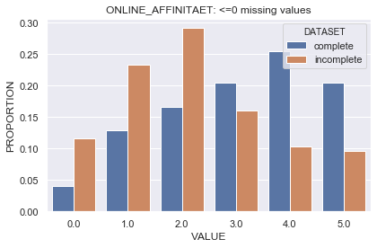

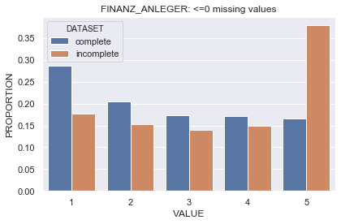

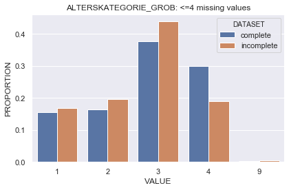

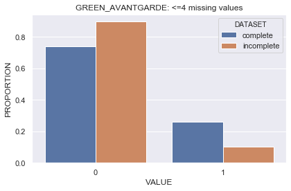

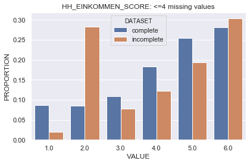

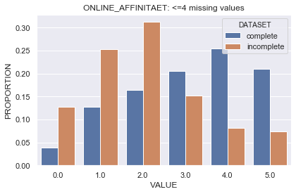

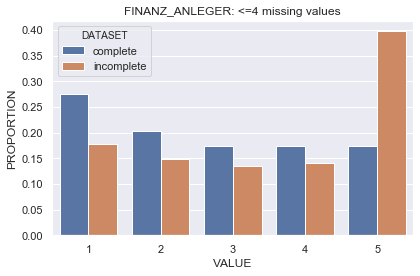

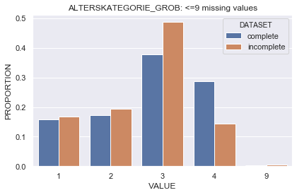

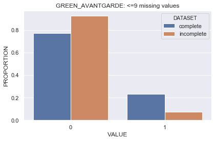

[3 more figures not shown]

```python
# compare distributions in random columns
#rand_idx = np.random.randint(low=0, high=len(azdias_cleaned.columns), size=5)
#compare_columns = azdias_cleaned.columns[idx]

# compare distributions in selected columns
compare_columns = ['ALTERSKATEGORIE_GROB', 'GREEN_AVANTGARDE', 'HH_EINKOMMEN_SCORE',
                   'ONLINE_AFFINITAET', 'FINANZ_ANLEGER']

missing_thresholds = [0, 4, 9]

# loop over missing thresholds
for missing in missing_thresholds:

    # separate the dataset depending on how many values are missing row-wise
    print("missing threshold = {}".format(missing))
    complete_rows, incomplete_rows = separate_rows_missing(azdias_cleaned, missing_threshold=missing)
    print("")

    for col in compare_columns:
        ax = plot_feature_distributions(col, complete_rows, incomplete_rows, plottitle=str(missing))
```

**Observations**

```python
# drop columns with more than 9 missing values
azdias_complete, azdias_incomplete = separate_rows_missing(azdias_cleaned, missing_threshold=9)
print(azdias_complete.shape)
```

```
# complete row fraction:   78.4%
# incomplete row fraction: 21.6%
(698462, 346)
```

### 1.4 Analyze categorical and binary features

In the following cells, a detailled analysis of the categorical and binary features is performed. These features need to be correctly encoded for the subsequent clustering analysis. Further, missing values need to be imputed prior to the final one-hot encoding of the categorical features.

```python
# show number of categorical and
feat_info['TYPE'].value_counts()
```

```
ordinal        311
categorical     18
numerical        9
binary           8
Name: TYPE, dtype: int64
```

#### 1.4.1 Check and encode binary features

```python
# show all non-ordinal features
feat_info[feat_info['TYPE'].isin(['binary'])]
```

|  | FEATURE | TYPE | UNKNOWN | DESCRIBED | COMMENT | DECISION |
| --- | --- | --- | --- | --- | --- | --- |
| 97 | DSL_FLAG | binary | [] | 0 | probably binary variable showing DSL internet ... | keep |
| 115 | GREEN_AVANTGARDE | binary | [] | 1 | NaN | keep |
| 305 | KONSUMZELLE | binary | [] | 0 | probably whether lives in KONSUMZELLE or not | keep |
| 318 | OST_WEST_KZ | binary | [-1] | 1 | re-encode to binary | re-encode to binary |
| 348 | SOHO_KZ | binary | [-1] | 1 | NaN | keep |
| 353 | UNGLEICHENN_FLAG | binary | [] | 0 | no infromation availabe on codes; could be inc... | maybe include |
| 355 | VERS_TYP | binary | [-1] | 1 | NaN | keep |
| 365 | ANREDE_KZ | binary | [-1,0] | 1 | NaN | keep |

```python
# check if all binary features are encoded correctly
for feature in list(feat_info[feat_info['TYPE'].isin(['binary'])]['FEATURE'].values):
    print(azdias_complete[feature].value_counts())
    print("")
```

```
1.0    691033
0.0      7429
Name: DSL_FLAG, dtype: int64

0    537674
1    160788
Name: GREEN_AVANTGARDE, dtype: int64

0.0    534865
1.0    163593
Name: KONSUMZELLE, dtype: int64

W    550713
O    147749
Name: OST_WEST_KZ, dtype: int64

0.0    692541
1.0      5921
Name: SOHO_KZ, dtype: int64

0.0    635637
1.0     62825
Name: UNGLEICHENN_FLAG, dtype: int64

2.0    359130
1.0    323007
Name: VERS_TYP, dtype: int64

2    360501
1    337961
Name: ANREDE_KZ, dtype: int64
```

**Observations**

- `OST_WEST_KZ` is encoded as string and needs to be re-encoded as binary (W=0, O=1)
- `VERS_TYP` is rather a categorical feature with two categories
  - it is encoded as binary here as follows:
    - 0 = "social-safety driven"
    - 1 = "individualistic-accepting risks"

```python
# re-encoding OST_WEST_KZ from string to binary (W=0, O=1)
azdias_complete.replace({'OST_WEST_KZ': {'W': 0, 'O': 1}}, inplace=True)
print(azdias_complete['OST_WEST_KZ'].value_counts())
```

```
0    550713
1    147749
Name: OST_WEST_KZ, dtype: int64
```

```python
# re-encoding VERS_TYP to binary feature
azdias_complete.replace({'VERS_TYP': {1.0: 0}}, inplace=True)
azdias_complete.replace({'VERS_TYP': {2.0: 1}}, inplace=True)
print(azdias_complete['VERS_TYP'].value_counts())
```

```
1.0    359130
0.0    323007
Name: VERS_TYP, dtype: int64
```

```python
# analyze correlation of the UNGLEICHENN_FLAG feature
azdias_complete.corrwith(azdias_complete['UNGLEICHENN_FLAG'], method='pearson').sort_values()
```

```
W_KEIT_KIND_HH        -0.242839
VK_DHT4A              -0.116983
CJT_KATALOGNUTZER     -0.100991
CJT_TYP_3             -0.090641
CJT_TYP_4             -0.089088
                         ...
LP_LEBENSPHASE_FEIN    0.258922
LP_FAMILIE_FEIN        0.263771
LP_FAMILIE_GROB        0.281013
ANZ_PERSONEN           0.323710
UNGLEICHENN_FLAG       1.000000
Length: 343, dtype: float64
```

**Observations**

#### 1.4.2 Check categorical features

```python
# show all non-ordinal features
feat_info[feat_info['TYPE'].isin(['categorical'])]
```

|  | FEATURE | TYPE | UNKNOWN | DESCRIBED | COMMENT | DECISION |
| --- | --- | --- | --- | --- | --- | --- |
| 3 | AKT_DAT_KL | categorical | [] | 0 | no infromation availabe on codes; | investigate |
| 18 | CAMEO_DEU_2015 | categorical | [XX,-1] | 1 | fine grained information | encode as number; one-hot encode |
| 20 | CAMEO_INTL_2015 | categorical | [XX,-1] | 1 | fine grained information | encode as number; one-hot encode |
| 21 | CJT_GESAMTTYP | categorical | [0] | 1 | NaN | one-hot encode |
| 58 | D19_KONSUMTYP | categorical | [] | 1 | many missing data | drop |
| 59 | D19_KONSUMTYP_MAX | categorical | [] | 0 | probably most frequent KONSUMTYP in cell; cont... | drop |
| 108 | FINANZTYP | categorical | [-1] | 1 | NaN | one-hot encode |
| 110 | GEBAEUDETYP | categorical | [-1,0] | 1 | NaN | one-hot encode |
| 114 | GFK_URLAUBERTYP | categorical | [] | 1 | NaN | one-hot encode |
| 306 | LP_FAMILIE_FEIN | categorical | [0] | 1 | NaN | one-hot encode |
| 307 | LP_FAMILIE_GROB | categorical | [0] | 1 | not needed as more detailed information is ava... | drop |
| 308 | LP_LEBENSPHASE_FEIN | categorical | [0] | 1 | very fine-grained information | investigate |
| 309 | LP_LEBENSPHASE_GROB | categorical | [0] | 1 | NaN | investigate |
| 315 | NATIONALITAET_KZ | categorical | [-1,0] | 1 | NaN | keep |
| 326 | PRAEGENDE_JUGENDJAHRE | categorical | [-1,0] | 1 | NaN | one-hot encode |
| 329 | RETOURTYP_BK_S | categorical | [0] | 1 | NaN | one-hot encode |
| 347 | SHOPPER_TYP | categorical | [-1] | 1 | NaN | one-hot encode |
| 364 | ZABEOTYP | categorical | [-1,9] | 1 | NaN | one-hot encode |

**categorical features to be kept and encoded**

- `CAMEO_INTL_2015`: multi-deminsional information; split into new features
- `CJT_GESAMTTYP`
- `D19_KONSUMTYP`
- `GFK_URLAUBERTYP`
- `LP_LEBENSPHASE_GROB`
- `PRAEGENDE_JUGENDJAHRE`: multi-dimensional information; split into new features
- `RETOURTYP_BK_S`
- `SHOPPER_TYP`
- `ZABEOTYP`

**categorical features to be dropped**

- `AKT_DAT_KL`: not documented; information missing
- `FINANZTYP`: already captured in other `FINANZ_*` features
- `CAMEO_DEUG_2015`: already captured in `CAMEO_INTL_2015`
- `CAMEO_DEU_2015`: fine grained version of the above feature; too detailed at this stage
- `D19_KONSUMTYP_MAX`: not documented; data not consistend with `D19_KONSUMTYP` feature
- `GEBAEUDETYP`: only indirect link to customer behaviour at first glance
- `LP_FAMILIE_FEIN`: fine grained information
- `LP_FAMILIE_GROB`: partially captured in `LP_LEBENSPHASE*` features
- `LP_LEBENSPHASE_FEIN`: fine grained information
- `NATIONALITAET_KZ`: nationality deduced from name; no reliable information about nationality

```python
# drop the above indentified categorical features
drop_categorical_features = ['AKT_DAT_KL', 'FINANZTYP', 'CAMEO_DEUG_2015', 'CAMEO_DEU_2015', 'D19_KONSUMTYP_MAX',
                             'GEBAEUDETYP', 'LP_FAMILIE_FEIN', 'LP_FAMILIE_GROB', 'LP_LEBENSPHASE_FEIN',
                             'NATIONALITAET_KZ']

azdias_complete.drop(drop_categorical_features, axis=1, inplace=True)
print(azdias_complete.shape)
```

```
(698462, 336)
```

```python
# remove dropped columns also from feat_info dataframe
feat_info = feat_info[~feat_info['FEATURE'].isin(drop_categorical_features)]
feat_info.shape
```

```
(336, 6)
```

```python
# encode multi-dimensional feature CAMEO_INTL_2015
azdias_encoded = pd.DataFrame(index=azdias_complete.index)
azdias_encoded['CAMEO_INTL_2015'] = azdias_complete['CAMEO_INTL_2015']
azdias_encoded['FAMILY_WEALTH'] = azdias_encoded['CAMEO_INTL_2015'].apply(lambda x: int(str(x)[0]) if pd.notna(x) else x)
azdias_encoded['FAMILY_TYPE'] = azdias_encoded['CAMEO_INTL_2015'].apply(lambda x: int(str(x)[1]) if pd.notna(x) else x)
azdias_encoded.head(10)
```

|  | CAMEO_INTL_2015 | FAMILY_WEALTH | FAMILY_TYPE |
| --- | --- | --- | --- |
| 1 | 51 | 5.0 | 1.0 |
| 2 | 24 | 2.0 | 4.0 |
| 3 | 12 | 1.0 | 2.0 |
| 4 | 43 | 4.0 | 3.0 |
| 5 | 54 | 5.0 | 4.0 |
| 6 | 22 | 2.0 | 2.0 |
| 7 | 14 | 1.0 | 4.0 |
| 8 | 13 | 1.0 | 3.0 |
| 9 | 15 | 1.0 | 5.0 |
| 10 | 51 | 5.0 | 1.0 |

```python
# encode multi-dimensional feature PRAEGENDE_JUGENDJAHRE
azdias_encoded['PRAEGENDE_JUGENDJAHRE'] = azdias_complete['PRAEGENDE_JUGENDJAHRE'].astype(str)

replace_decades = {'1.0': 1940, '2.0': 1940, '3.0': 1950, '4.0': 1950, '5.0': 1960, '6.0': 1960, '7.0': 1960,
                   '8.0': 1970, '9.0': 1970, '10.0': 1980, '11.0': 1980, '12.0': 1980, '13.0': 1980,
                   '14.0': 1990, '15.0': 1990}

replace_avantgarde = {'1.0': 0, '2.0': 1, '3.0': 0, '4.0': 1, '5.0': 0, '6.0': 1, '7.0': 1,
                      '8.0': 0, '9.0': 1, '10.0': 0, '11.0': 1, '12.0': 0, '13.0': 1,
                      '14.0': 0, '15.0': 1}

# replace values and add to the dataframe of encoded variables
azdias_encoded['YOUTH_DECADE'] = azdias_encoded.replace({'PRAEGENDE_JUGENDJAHRE': replace_decades})['PRAEGENDE_JUGENDJAHRE']
azdias_encoded['MAIN_AVANT'] = azdias_encoded.replace({'PRAEGENDE_JUGENDJAHRE': replace_avantgarde})['PRAEGENDE_JUGENDJAHRE']

# convert all columns to float
azdias_encoded = azdias_encoded.astype(float)
azdias_encoded.head(10)
```

|  | CAMEO_INTL_2015 | FAMILY_WEALTH | FAMILY_TYPE | PRAEGENDE_JUGENDJAHRE | YOUTH_DECADE | MAIN_AVANT |
| --- | --- | --- | --- | --- | --- | --- |
| 1 | 51.0 | 5.0 | 1.0 | 14.0 | 1990.0 | 0.0 |
| 2 | 24.0 | 2.0 | 4.0 | 15.0 | 1990.0 | 1.0 |
| 3 | 12.0 | 1.0 | 2.0 | 8.0 | 1970.0 | 0.0 |
| 4 | 43.0 | 4.0 | 3.0 | 8.0 | 1970.0 | 0.0 |
| 5 | 54.0 | 5.0 | 4.0 | 3.0 | 1950.0 | 0.0 |
| 6 | 22.0 | 2.0 | 2.0 | 10.0 | 1980.0 | 0.0 |
| 7 | 14.0 | 1.0 | 4.0 | 8.0 | 1970.0 | 0.0 |
| 8 | 13.0 | 1.0 | 3.0 | 11.0 | 1980.0 | 1.0 |
| 9 | 15.0 | 1.0 | 5.0 | 15.0 | 1990.0 | 1.0 |
| 10 | 51.0 | 5.0 | 1.0 | 3.0 | 1950.0 | 0.0 |

```python
# drop original columns from dataframe of encoded features
azdias_encoded.drop(['PRAEGENDE_JUGENDJAHRE', 'CAMEO_INTL_2015'], axis=1, inplace=True)
azdias_encoded.head(10)
```

|  | FAMILY_WEALTH | FAMILY_TYPE | YOUTH_DECADE | MAIN_AVANT |
| --- | --- | --- | --- | --- |
| 1 | 5.0 | 1.0 | 1990.0 | 0.0 |
| 2 | 2.0 | 4.0 | 1990.0 | 1.0 |
| 3 | 1.0 | 2.0 | 1970.0 | 0.0 |
| 4 | 4.0 | 3.0 | 1970.0 | 0.0 |
| 5 | 5.0 | 4.0 | 1950.0 | 0.0 |
| 6 | 2.0 | 2.0 | 1980.0 | 0.0 |
| 7 | 1.0 | 4.0 | 1970.0 | 0.0 |
| 8 | 1.0 | 3.0 | 1980.0 | 1.0 |
| 9 | 1.0 | 5.0 | 1990.0 | 1.0 |
| 10 | 5.0 | 1.0 | 1950.0 | 0.0 |

```python
# remove original multi-dimensinal features from dataset
azdias_complete.drop(['PRAEGENDE_JUGENDJAHRE', 'CAMEO_INTL_2015'], axis=1, inplace=True)

# add new features from multi-dimensional features to dataframe
azdias_features = azdias_complete.join(azdias_encoded)
```

```python
# check types of all features (should not contain object (str))
azdias_features.info()
```

```
<class 'pandas.core.frame.DataFrame'>
Int64Index: 698462 entries, 1 to 891220
Columns: 338 entries, ANZ_HAUSHALTE_AKTIV to MAIN_AVANT
dtypes: float64(255), int64(83)
memory usage: 1.8 GB
```

```python
# convert all features to float
azdias_features = azdias_features.astype(float)
azdias_features.info()
```

```
<class 'pandas.core.frame.DataFrame'>
Int64Index: 698462 entries, 1 to 891220
Columns: 338 entries, ANZ_HAUSHALTE_AKTIV to MAIN_AVANT
dtypes: float64(338)
memory usage: 1.8 GB
```

### 1.5 Analyze correlations between features

```python
%%time
# calculate correlation coefficients between all features
corr_coeffs = azdias_features.corr(method='pearson')
```

```
CPU times: user 2min 36s, sys: 2.17 s, total: 2min 38s
Wall time: 2min 40s
```

```python
# set all weak and medium correlations coefficiets to NaN
corr_coeffs[corr_coeffs.abs() < 0.8] = np.nan

# calculate how many features are strongly correlated with each other
print((corr_coeffs.notnull().sum().sum()-corr_coeffs.shape[0])/2.0)
```

```
86.0
```

```python
# print all strongly correlated features
for col in corr_coeffs.columns:
    if np.abs(corr_coeffs[col].notnull().sum()) > 1.0:
        print(corr_coeffs[col][corr_coeffs[col].notnull()])
        print()
```

```
ANZ_HAUSHALTE_AKTIV           1.000000
ANZ_STATISTISCHE_HAUSHALTE    0.982024
Name: ANZ_HAUSHALTE_AKTIV, dtype: float64

ANZ_HAUSHALTE_AKTIV           0.982024
ANZ_STATISTISCHE_HAUSHALTE    1.000000
Name: ANZ_STATISTISCHE_HAUSHALTE, dtype: float64

CJT_TYP_1       1.000000
CJT_TYP_2       0.886248
CJT_TYP_3      -0.819519
CJT_TYP_5      -0.830279
YOUTH_DECADE    0.813613
Name: CJT_TYP_1, dtype: float64

CJT_TYP_1       0.886248
CJT_TYP_2       1.000000
CJT_TYP_3      -0.839905
CJT_TYP_5      -0.816206
YOUTH_DECADE    0.803851
Name: CJT_TYP_2, dtype: float64

CJT_TYP_1   -0.819519
CJT_TYP_2   -0.839905
CJT_TYP_3    1.000000
Name: CJT_TYP_3, dtype: float64

CJT_TYP_1   -0.830279
CJT_TYP_2   -0.816206
CJT_TYP_5    1.000000
Name: CJT_TYP_5, dtype: float64

D19_BANKEN_ANZ_12    1.000000
D19_BANKEN_ANZ_24    0.814944
Name: D19_BANKEN_ANZ_12, dtype: float64

D19_BANKEN_ANZ_12    0.814944
D19_BANKEN_ANZ_24    1.000000
D19_BANKEN_DATUM    -0.805443
Name: D19_BANKEN_ANZ_24, dtype: float64
```

[output cut: 410 more lines]

```
SEMIO_VERT   -0.854433
ANREDE_KZ     1.000000
Name: ANREDE_KZ, dtype: float64

CJT_TYP_1           0.813613
CJT_TYP_2           0.803851
FINANZ_SPARER       0.842346
FINANZ_VORSORGER   -0.804090
KOMBIALTER         -0.875373
YOUTH_DECADE        1.000000
Name: YOUTH_DECADE, dtype: float64

GREEN_AVANTGARDE    1.0
MAIN_AVANT          1.0
Name: MAIN_AVANT, dtype: float64
```

**Observations:**

- drop `ANZ_STATISTISCHE_HAUSHALTE` as it is **not described** and **strongly correlated** with `ANZ_HAUSHALTE_AKTIV`
- drop `CJT_TYP_*` as it is **not described** and **strongly correlated** with `YOUTH_DECADE` and among each other
- drop `D19_BANKEN_ANZ_12` as it is **strongly correlated** with `D19_BANKEN_ANZ_24`
- drop `D19_BANKEN_DATUM` as it is **strongly correlated** with `D19_BANKEN_ANZ_24`
- drop `D19_BANKEN_ONLINE_DATUM` as it is **strongly correlated** with `D19_BANKEN_ONLINE_QUOTE_12`
- drop `D19_GESAMT_ANZ_12` as it is **strongly correlated** with `D19_GESAMT_ANZ_24`
- drop `D19_GESAMT_DATUM` as it is **strongly correlated** with `D19_GESAMT_ANZ_24` and others
- drop `D19_GESAMT_ONLINE_DATUM` as it is **strongly correlated** with `D19_GESAMT_ANZ_24` and `D19_GESAMT_ONLINE_QUOTE_12`
- drop `D19_TELKO_DATUM` as it is **strongly correlated** with `D19_TELKO_ANZ_24`
- drop `D19_VERSAND_ANZ_12` as it is **strongly correlated** with `D19_VERSAND_ANZ_24`
- drop `D19_VERSAND_DATUM` as it is **strongly correlated** with `D19_VERSAND_ANZ_24`
- drop `D19_VERSAND_ONLINE_DATUM` as it is **strongly correlated** with `D19_VERSAND_ONLINE_QUOTE_12`
- drop `D19_VERSI_ANZ_12` as it is **strongly correlated** with `D19_VERSI_ANZ_24`
- drop `D19_VERSI_DATUM` as it is **strongly correlated** with `D19_VERSI_ANZ_24`
- drop `GREEN_AVANTGARDE` as it is **strongly correlated** with `MAIN_AVANT`
- drop `KBA05_HERST*` as they are **strongly correlated** with `KBA05_KRSHERST*` (compared to country average)
- drop `KBA05_SEG*` as they are **strongly correlated** with `KBA05_KRSKLEIN, _KRSOBER` (compared to country average)
- drop `KBA05_ZUL*` as they are **strongly correlated** with `KBA05_KRSZUL` (compared to country average)
- drop `KBA13_HALTER_*` as they are **strongly correlated** with `KBA13_ALTERHALTER_*`
- drop `PLZ8_*` as they are **strongly correlated** with corresponding `KBA13_*`
- drop `KBA13_FAB_SONSTIGE` as it is **strongly correlated** with `KBA13_HERST_SONST`
- drop `KBA13_HERST_AUDI_VW` as it is **strongly correlated** with `KBA13_VW`
- drop `KBA13_HERST_BMW_BENZ` as it is **strongly correlated** with `KBA13_MERCEDES`
- drop `KBA13_KMH_0_140` as it is **strongly correlated** with `KBA13_KMH_140`
- drop `KBA13_KMH_211` as it is **strongly correlated** with `KBA13_KMH_250`
- drop `LP_STATUS_FEIN` as it is **strongly correlated** with `LP_STATUS_GROB`
- drop `ORTSGR_KLS9` as it is **strongly correlated** with `EWDICHTE`
- drop `VK_ZG11` as it is **strongly correlated** with `VK_DISTANZ`
- drop `VK_DHT4A` as it is **strongly correlated** with `VK_DISTANZ`

```python
# list with strongly correlated features to be dropped
corr_columns = ['ANZ_STATISTISCHE_HAUSHALTE', 'CJT_TYP_1', 'CJT_TYP_2', 'CJT_TYP_3', 'CJT_TYP_4', 'CJT_TYP_5', 'CJT_TYP_6',
'D19_BANKEN_ANZ_12', 'D19_BANKEN_DATUM', 'D19_BANKEN_ONLINE_DATUM', 'D19_GESAMT_ANZ_12', 'D19_GESAMT_DATUM',
'D19_GESAMT_ONLINE_DATUM', 'D19_TELKO_DATUM', 'D19_VERSAND_ANZ_12', 'D19_VERSAND_DATUM', 'D19_VERSAND_ONLINE_DATUM',
'D19_VERSI_ANZ_12', 'D19_VERSI_DATUM', 'GREEN_AVANTGARDE', 'KBA05_HERST1', 'KBA05_HERST2', 'KBA05_HERST3',
'KBA05_HERST4', 'KBA05_HERST5', 'KBA05_SEG1', 'KBA05_SEG2', 'KBA05_SEG3', 'KBA05_SEG4', 'KBA05_SEG5', 'KBA05_SEG6',
 'KBA05_SEG7', 'KBA05_SEG8', 'KBA05_SEG9', 'KBA05_SEG10', 'KBA05_ZUL1', 'KBA05_ZUL2', 'KBA05_ZUL3', 'KBA05_ZUL4',
'KBA13_HALTER_20', 'KBA13_HALTER_25', 'KBA13_HALTER_30', 'KBA13_HALTER_35', 'KBA13_HALTER_40', 'KBA13_HALTER_45',
'KBA13_HALTER_50', 'KBA13_HALTER_55', 'KBA13_HALTER_60', 'KBA13_HALTER_65', 'PLZ8_ANTG1', 'PLZ8_ANTG2',
'PLZ8_ANTG3', 'PLZ8_ANTG4', 'PLZ8_BAUMAX', 'PLZ8_GBZ', 'PLZ8_HHZ', 'KBA13_FAB_SONSTIGE',
'KBA13_HERST_AUDI_VW', 'KBA13_HERST_BMW_BENZ', 'KBA13_KMH_0_140', 'KBA13_KMH_211', 'LP_STATUS_FEIN',
'ORTSGR_KLS9', 'VK_ZG11', 'VK_DHT4A']
```

```python
# drop strongly correlated columns
azdias_features.drop(corr_columns, axis=1, inplace=True)
azdias_features.shape
```

```
(698462, 273)
```

```python
# remove dropped columns also from feat_info dataframe
feat_info = feat_info[~feat_info['FEATURE'].isin(corr_columns)]
feat_info = feat_info[~feat_info['FEATURE'].isin(['PRAEGENDE_JUGENDJAHRE', 'CAMEO_INTL_2015'])]
feat_info.shape
```

```
(269, 6)
```

**Note:** the difference in shape between the dataframe and the feature info are the 4 columns `FAMILY_TYPE`, `FAMILY_WEALTH`, `YOUTH_DECADE`, and `MAIN_AVANT`.

### 1.6 Impute missing values

As up to 9 missing values per row were allowed to use 78% of the data, the missing values need to be imputed. As most features are categorical or ordinal features, and as the numerical features have highly skewed distributions, missing data will be imputed using the **median value** of each feature.

```python
# check number of missing values before imputation
azdias_features.isna().sum().sum()
```

```
1270545
```

```python
# impute missing values using median strategy
azdias_features.fillna(azdias_features.median(axis=0), inplace=True)
```

```python
# check number of missing values after imputation
azdias_features.isna().sum().sum()
```

```
0
```

### 1.7 One-hot encode categorical features

After cleaning of the dataset and imputing missing values, the categorical features are one-hot encoded for the subsequent clustering analysis.

```python
# one-hot encode categorical features
categorical_variables = ['CJT_GESAMTTYP', 'D19_KONSUMTYP', 'GFK_URLAUBERTYP', 'LP_LEBENSPHASE_GROB',
                         'RETOURTYP_BK_S', 'SHOPPER_TYP', 'ZABEOTYP']

azdias_onehot = pd.get_dummies(azdias_features[categorical_variables],
                               columns=categorical_variables).astype(float)

azdias_onehot
```

|  | CJT_GESAMTTYP_1.0 | CJT_GESAMTTYP_2.0 | CJT_GESAMTTYP_3.0 | CJT_GESAMTTYP_4.0 | CJT_GESAMTTYP_5.0 | CJT_GESAMTTYP_6.0 | D19_KONSUMTYP_1.0 | D19_KONSUMTYP_2.0 | D19_KONSUMTYP_3.0 | D19_KONSUMTYP_4.0 | ... | SHOPPER_TYP_0.0 | SHOPPER_TYP_1.0 | SHOPPER_TYP_2.0 | SHOPPER_TYP_3.0 | ZABEOTYP_1.0 | ZABEOTYP_2.0 | ZABEOTYP_3.0 | ZABEOTYP_4.0 | ZABEOTYP_5.0 | ZABEOTYP_6.0 |
| --- | --- | --- | --- | --- | --- | --- | --- | --- | --- | --- | --- | --- | --- | --- | --- | --- | --- | --- | --- | --- | --- |
| 1 | 0.0 | 0.0 | 0.0 | 0.0 | 1.0 | 0.0 | 0.0 | 0.0 | 0.0 | 0.0 | ... | 0.0 | 0.0 | 0.0 | 1.0 | 0.0 | 0.0 | 0.0 | 0.0 | 1.0 | 0.0 |
| 2 | 0.0 | 0.0 | 1.0 | 0.0 | 0.0 | 0.0 | 0.0 | 0.0 | 0.0 | 0.0 | ... | 0.0 | 0.0 | 1.0 | 0.0 | 0.0 | 0.0 | 0.0 | 0.0 | 1.0 | 0.0 |
| 3 | 0.0 | 1.0 | 0.0 | 0.0 | 0.0 | 0.0 | 0.0 | 0.0 | 0.0 | 0.0 | ... | 0.0 | 1.0 | 0.0 | 0.0 | 0.0 | 0.0 | 1.0 | 0.0 | 0.0 | 0.0 |
| 4 | 0.0 | 0.0 | 0.0 | 0.0 | 1.0 | 0.0 | 1.0 | 0.0 | 0.0 | 0.0 | ... | 0.0 | 0.0 | 1.0 | 0.0 | 0.0 | 0.0 | 0.0 | 1.0 | 0.0 | 0.0 |
| 5 | 0.0 | 1.0 | 0.0 | 0.0 | 0.0 | 0.0 | 0.0 | 0.0 | 0.0 | 1.0 | ... | 1.0 | 0.0 | 0.0 | 0.0 | 0.0 | 0.0 | 0.0 | 1.0 | 0.0 | 0.0 |
| ... | ... | ... | ... | ... | ... | ... | ... | ... | ... | ... | ... | ... | ... | ... | ... | ... | ... | ... | ... | ... | ... |
| 891216 | 0.0 | 0.0 | 0.0 | 0.0 | 1.0 | 0.0 | 1.0 | 0.0 | 0.0 | 0.0 | ... | 0.0 | 0.0 | 0.0 | 1.0 | 0.0 | 0.0 | 0.0 | 1.0 | 0.0 | 0.0 |
| 891217 | 0.0 | 0.0 | 0.0 | 1.0 | 0.0 | 0.0 | 0.0 | 0.0 | 0.0 | 0.0 | ... | 0.0 | 0.0 | 1.0 | 0.0 | 0.0 | 0.0 | 0.0 | 0.0 | 0.0 | 1.0 |
| 891218 | 0.0 | 0.0 | 0.0 | 1.0 | 0.0 | 0.0 | 0.0 | 0.0 | 1.0 | 0.0 | ... | 0.0 | 0.0 | 1.0 | 0.0 | 0.0 | 0.0 | 0.0 | 1.0 | 0.0 | 0.0 |
| 891219 | 0.0 | 0.0 | 1.0 | 0.0 | 0.0 | 0.0 | 0.0 | 0.0 | 0.0 | 0.0 | ... | 1.0 | 0.0 | 0.0 | 0.0 | 0.0 | 0.0 | 0.0 | 0.0 | 1.0 | 0.0 |
| 891220 | 1.0 | 0.0 | 0.0 | 0.0 | 0.0 | 0.0 | 0.0 | 0.0 | 0.0 | 0.0 | ... | 0.0 | 0.0 | 1.0 | 0.0 | 0.0 | 0.0 | 1.0 | 0.0 | 0.0 | 0.0 |

698462 rows × 52 columns

```python
# remove original non-encoded columns from original dataframe and append one-hot encoded features
print(azdias_features.shape)

azdias_features.drop(categorical_variables, axis=1, inplace=True)
azdias_final = azdias_features.join(azdias_onehot)

print(azdias_final.shape)
```

```
(698462, 273)
(698462, 318)
```

```python
# check types
azdias_final.info()
```

```
<class 'pandas.core.frame.DataFrame'>
Int64Index: 698462 entries, 1 to 891220
Columns: 318 entries, ANZ_HAUSHALTE_AKTIV to ZABEOTYP_6.0
dtypes: float64(318)
memory usage: 1.7 GB
```

```python
# check missing values
azdias_final.isna().sum().sum()
```

```
0
```

### 1.8 Summarize data wrangling in cleaning function

```python
# cleaning function to prepare data
def clean_data(df, missing_values, remove_lines=True, lines_threshold=9, impute=True):
    """
    Perform feature trimming, re-encoding, and engineering for demographics
    data

    INPUT: Demographics DataFrame
    OUTPUT: Trimmed and cleaned demographics DataFrame
    """
    # create copy of dataframe
    df_cleaned = df.copy()

    # 1. replace missing and unknown values by NaN, and remove columns and lines with many missing values

    # loop over columns and replace missing/unknown data skipping columns without missing/unknown codes
    for i, col in enumerate(df_cleaned.columns):
        if missing_values[i] != []:
            df_cleaned[col] = df[col].replace(missing_values[i], np.NaN)

    # drop columns with many missing values and with non-related information (e.g. number of entry)
    drop_columns_missing = ['ALTER_KIND4', 'TITEL_KZ', 'ALTER_KIND3', 'ALTER_KIND2', 'ALTER_KIND1', 'VHA',
                            'AGER_TYP', 'EXTSEL992', 'KK_KUNDENTYP', 'KBA05_BAUMAX', 'VERDICHTUNGSRAUM',
                            'D19_LETZTER_KAUF_BRANCHE', 'GEBURTSJAHR', 'ALTER_HH', 'ALTERSKATEGORIE_FEIN',
                            'LNR', 'EINGEFUEGT_AM', 'GEMEINDETYP', 'HH_DELTA_FLAG', 'VHN']

    df_cleaned.drop(drop_columns_missing, axis=1, inplace=True)

    # drop rows with more than 9 missing values
    if remove_lines == True:
        df_cleaned, _ = separate_rows_missing(df_cleaned, missing_threshold=lines_threshold)

    # drop unexplained or unconsistent categorical features
    drop_categorical_features = ['AKT_DAT_KL', 'FINANZTYP', 'CAMEO_DEUG_2015', 'CAMEO_DEU_2015',
                                 'D19_KONSUMTYP_MAX', 'GEBAEUDETYP', 'LP_FAMILIE_FEIN', 'LP_FAMILIE_GROB',
                                 'LP_LEBENSPHASE_FEIN', 'NATIONALITAET_KZ']

    df_cleaned.drop(drop_categorical_features, axis=1, inplace=True)

    # 2. re-encoding features

    # re-encoding OST_WEST_KZ from string to binary (W=0, O=1) inplace
    df_cleaned.replace({'OST_WEST_KZ': {'W': 0, 'O': 1}}, inplace=True)

    # re-encoding VERS_TYP to binary feature
    df_cleaned.replace({'VERS_TYP': {1.0: 0}}, inplace=True)
    df_cleaned.replace({'VERS_TYP': {2.0: 1}}, inplace=True)

    # re-encoding categorical features
    # CAMEO_INTL_2015
    df_encoded = pd.DataFrame(index=df_cleaned.index)
    df_encoded['CAMEO_INTL_2015'] = df_cleaned['CAMEO_INTL_2015']
    df_encoded['FAMILY_WEALTH'] = df_cleaned['CAMEO_INTL_2015'].apply(lambda x: int(str(x)[0]) if pd.notna(x) else x)
    df_encoded['FAMILY_TYPE'] = df_cleaned['CAMEO_INTL_2015'].apply(lambda x: int(str(x)[1]) if pd.notna(x) else x)

    # PRAEGENDE_JUGENDJAHRE
    df_encoded['PRAEGENDE_JUGENDJAHRE'] = df_cleaned['PRAEGENDE_JUGENDJAHRE'].astype(str)

    replace_decades = {'1.0': 1940, '2.0': 1940, '3.0': 1950, '4.0': 1950, '5.0': 1960, '6.0': 1960, '7.0': 1960,
                       '8.0': 1970, '9.0': 1970, '10.0': 1980, '11.0': 1980, '12.0': 1980, '13.0': 1980,
                       '14.0': 1990, '15.0': 1990}

    replace_avantgarde = {'1.0': 0, '2.0': 1, '3.0': 0, '4.0': 1, '5.0': 0, '6.0': 1, '7.0': 1,
                          '8.0': 0, '9.0': 1, '10.0': 0, '11.0': 1, '12.0': 0, '13.0': 1,
                          '14.0': 0, '15.0': 1}

    # replace values and add to the dataframe of encoded variables
    df_encoded['YOUTH_DECADE'] = df_encoded.replace({'PRAEGENDE_JUGENDJAHRE': replace_decades})['PRAEGENDE_JUGENDJAHRE']
    df_encoded['MAIN_AVANT'] = df_encoded.replace({'PRAEGENDE_JUGENDJAHRE': replace_avantgarde})['PRAEGENDE_JUGENDJAHRE']

    # drop original columns from dataframe of encoded and original features and join new features to dataframe
    df_encoded.drop(['PRAEGENDE_JUGENDJAHRE', 'CAMEO_INTL_2015'], axis=1, inplace=True)
    df_cleaned.drop(['PRAEGENDE_JUGENDJAHRE', 'CAMEO_INTL_2015'], axis=1, inplace=True)
    df_cleaned = df_cleaned.join(df_encoded)

    # convert all values to float
    df_cleaned = df_cleaned.astype(float)

    # drop columns that are strongly correlated to other features
    drop_corr_columns = ['ANZ_STATISTISCHE_HAUSHALTE', 'CJT_TYP_1', 'CJT_TYP_2', 'CJT_TYP_3', 'CJT_TYP_4',
                         'CJT_TYP_5', 'CJT_TYP_6', 'D19_BANKEN_ANZ_12', 'D19_BANKEN_DATUM',
                         'D19_BANKEN_ONLINE_DATUM', 'D19_GESAMT_ANZ_12', 'D19_GESAMT_DATUM',
                         'D19_GESAMT_ONLINE_DATUM', 'D19_TELKO_DATUM', 'D19_VERSAND_ANZ_12',
                         'D19_VERSAND_DATUM', 'D19_VERSAND_ONLINE_DATUM',
                         'D19_VERSI_ANZ_12', 'D19_VERSI_DATUM', 'GREEN_AVANTGARDE',
                         'KBA05_HERST1', 'KBA05_HERST2', 'KBA05_HERST3',
                         'KBA05_HERST4', 'KBA05_HERST5',
                         'KBA05_SEG1', 'KBA05_SEG2', 'KBA05_SEG3', 'KBA05_SEG4', 'KBA05_SEG5', 'KBA05_SEG6',
                         'KBA05_SEG7', 'KBA05_SEG8', 'KBA05_SEG9', 'KBA05_SEG10',
                         'KBA05_ZUL1', 'KBA05_ZUL2', 'KBA05_ZUL3', 'KBA05_ZUL4',
                         'KBA13_HALTER_20', 'KBA13_HALTER_25', 'KBA13_HALTER_30', 'KBA13_HALTER_35',
                         'KBA13_HALTER_40', 'KBA13_HALTER_45', 'KBA13_HALTER_50', 'KBA13_HALTER_55',
                         'KBA13_HALTER_60', 'KBA13_HALTER_65', 'PLZ8_ANTG1', 'PLZ8_ANTG2',
                         'PLZ8_ANTG3', 'PLZ8_ANTG4', 'PLZ8_BAUMAX', 'PLZ8_GBZ', 'PLZ8_HHZ',
                         'KBA13_FAB_SONSTIGE', 'KBA13_HERST_AUDI_VW', 'KBA13_HERST_BMW_BENZ',
                         'KBA13_KMH_0_140', 'KBA13_KMH_211', 'LP_STATUS_FEIN',
                         'ORTSGR_KLS9', 'VK_ZG11', 'VK_DHT4A']

    df_cleaned.drop(drop_corr_columns, axis=1, inplace=True)

    # impute missing values using median
    if impute == True:
        df_cleaned.fillna(df_cleaned.median(axis=0), inplace=True)

    # one-hot encode categorical features
    categorical_variables = ['CJT_GESAMTTYP', 'D19_KONSUMTYP', 'GFK_URLAUBERTYP', 'LP_LEBENSPHASE_GROB',
                             'RETOURTYP_BK_S', 'SHOPPER_TYP', 'ZABEOTYP']

    df_onehot = pd.get_dummies(df_cleaned[categorical_variables],
                               columns=categorical_variables).astype(float)

    # remove original non-encoded columns from original dataframe and append one-hot encoded features
    df_cleaned.drop(categorical_variables, axis=1, inplace=True)
    df_cleaned = df_cleaned.join(df_onehot)

    return df_cleaned
```

```python
df_cleaned = clean_data(azdias, missing_list)
```

```
# complete row fraction:   78.4%
# incomplete row fraction: 21.6%
```

```python
df_cleaned.info()
```

```
<class 'pandas.core.frame.DataFrame'>
Int64Index: 698462 entries, 1 to 891220
Columns: 318 entries, ANZ_HAUSHALTE_AKTIV to ZABEOTYP_6.0
dtypes: float64(318)
memory usage: 1.7 GB
```

```python
# test if cleaning function arrives at the same dataframe as the manual cleaning (check should return 0)
df_check = df_cleaned != azdias_final
df_check.sum().sum()
```

```
0
```

```python
# save cleaned dataframe
df_cleaned.to_pickle('azdias_population_cleaned.pkl')
```

## Part 2: Customer Segmentation Report

The main bulk of your analysis will come in this part of the project. Here, you should use unsupervised learning techniques to describe the relationship between the demographics of the company's existing customers and the general population of Germany. By the end of this part, you should be able to describe parts of the general population that are more likely to be part of the mail-order company's main customer base, and which parts of the general population are less so.

### 2.1 Principal component analysis

```python
# check for missing values
df_cleaned.isna().sum().sum()
```

```
0
```

```python
# apply feature scaling to the general demographic data
from sklearn.preprocessing import StandardScaler

scaler = StandardScaler()
data_std = scaler.fit_transform(df_cleaned)
```

```python
# apply PCA to the scaled data
from sklearn.decomposition import PCA

pca = PCA(random_state=0)
data_pca = pca.fit_transform(data_std)
```

```python
# implement function to plot explained variance from PCA
def plot_pca(pca, limit=20):

    n_PC = len(pca.explained_variance_ratio_)
    idx_PC = range(1, n_PC+1)
    var_PC = pca.explained_variance_ratio_
    cum_var_PC = np.cumsum(var_PC)

    fig = plt.figure(figsize=(8,8))
    plt.subplot(2, 1, 1)
    plt.bar(idx_PC[:limit], var_PC[:limit], linewidth=0.0)
    plt.xticks(range(1,limit+1))
    plt.ylim(0.0, np.around(np.max(var_PC), decimals=1))
    for i in range(0, limit):
        plt.annotate('%.1f%%' % (100.0*var_PC[i]), (i+1, var_PC[i]+0.005), ha='center',
                     rotation=90.0, weight='bold', color=tableau10[0])
    plt.xlabel('principal component')
    plt.ylabel('explained variance')

    plt.subplot(2, 1, 2)
    plt.plot(idx_PC, cum_var_PC, '.--', color=tableau10[1])
    plt.hlines([0.5, 0.66, 0.8, 0.9], xmin=1, xmax=n_PC, linestyles='--')
    plt.ylim(ymin=0.0)
    plt.xlabel('number of principal components')
    plt.ylabel('cumulated explained variance')
    plt.annotate('50%', (1, 0.52), weight='bold', color=tableau10[1])
    plt.annotate('66%', (1, 0.68), weight='bold', color=tableau10[1])
    plt.annotate('80%', (1, 0.82), weight='bold', color=tableau10[1])
    plt.annotate('90%', (1, 0.92), weight='bold', color=tableau10[1])

    fig.tight_layout()
    fig.savefig('plots/PCA.png', dpi=300.0)
```

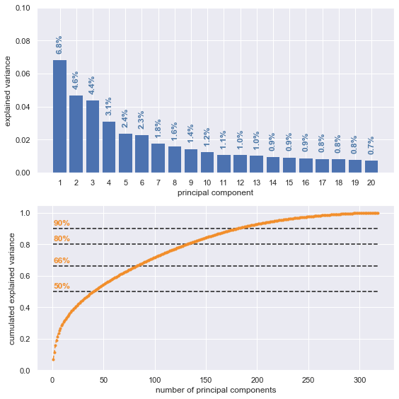

```python
# investigate the variance accounted for by each principal component.
plot_pca(pca, limit=20)
```

```python
cum_var_PC = np.cumsum(pca.explained_variance_ratio_)

for i in range(9,200,10):
    print('%i PCs: %.1f%% variance explained' % (i+1, cum_var_PC[i]*100.0))
```

```
10 PCs: 29.5% variance explained
20 PCs: 38.4% variance explained
30 PCs: 44.8% variance explained
40 PCs: 50.0% variance explained
50 PCs: 54.4% variance explained
60 PCs: 58.4% variance explained
70 PCs: 62.0% variance explained
80 PCs: 65.4% variance explained
90 PCs: 68.6% variance explained
100 PCs: 71.6% variance explained
110 PCs: 74.5% variance explained
120 PCs: 77.1% variance explained
130 PCs: 79.6% variance explained
140 PCs: 82.0% variance explained
150 PCs: 84.2% variance explained
160 PCs: 86.2% variance explained
170 PCs: 88.1% variance explained
180 PCs: 89.9% variance explained
190 PCs: 91.4% variance explained
200 PCs: 92.8% variance explained
```

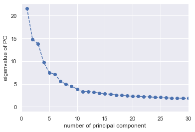

```python
# create scree plot of PC eigenvalues
fig = plt.figure(figsize=(6,4))
plt.plot(range(1,pca.n_components_+1), pca.explained_variance_, 'o--')
plt.xlim(0.0, 30.0)
plt.xlabel('number of principal component')
plt.ylabel('eigenvalue of PC')
```

**Observations**

- 21% of the variance are explained by the first 5 PCs
- with 40 PCs, at least 50% of the variance can be captured
- with 140 PCs, at least 80% of the variance can be captured
- to capture 90% of the variance in the data, 190 PCs are required
- **decision:** use 10 PCs for the clustering analysis to avoid PCs with explained variance equal or below 1% and a too fine-grained feature space.

```python
# re-apply PCA to the data while selecting for number of components to retain.
n_pc = 10
pca_n = PCA(n_components=n_pc, random_state=0)
data_pca_n = pca_n.fit_transform(data_std)
```

```python
# create dataframe with PCs and explained variance values
n_components = pca_n.components_.shape[0]
df_pca_weights = pd.DataFrame(pca_n.components_, columns=df_cleaned.columns,
                              index=['PC{}'.format(i) for i in range(1, n_components+1)])

df_pca_weights['EXPLAINED_VARIANCE_RATIO'] = pca_n.explained_variance_ratio_.reshape((n_components, -1))
```

```python
# implement function to analyze and plot feature weights in PC
def plot_pca_weights(df, component, threshold=0.1):

    # extract explained variance and weights
    explained_variance = float(df.iloc[component-1, -1])
    weights = df.iloc[component-1, 0:-1].values
    features = np.array((df.columns[0:-1]))

    # sort values and features by weight
    idx = np.argsort(-1.0*weights)
    weights_sorted = weights[idx]
    features_sorted = features[idx]


    # reduce to features with weights higher +-0.1
    weights_pos = np.trim_zeros(np.where(weights_sorted >= threshold, weights_sorted, 0.0))
    weights_neg = np.trim_zeros(np.where(weights_sorted <= -1.0*threshold, weights_sorted, 0.0))
    weights_main = np.hstack((weights_pos, weights_neg))

    n_pos = len(weights_pos)
    n_neg = len(weights_neg)
    n_main = n_pos + n_neg

    features_main = np.hstack((features_sorted[0:n_pos], features_sorted[-n_neg:]))
    feature_idx = range(1,n_main+1)


    # plot
    plt.figure(figsize=(15,10))
    ax = plt.gca()
    plt.bar(feature_idx, weights_main, align='center', linewidth=0.0)
    plt.xticks(feature_idx)
    ax.set_xticklabels([])
    for i in range(n_pos):
        plt.annotate('%s' % features_main[i], (i+1, -0.01), rotation=90, ha='center', va='top', weight='bold')
        plt.annotate('%.1f%%' % (weights_main[i]*100.0), (i+1, weights_main[i]+0.01),
                     rotation=90, ha='center', va='bottom', weight='bold')

    for i in range(n_neg):
        plt.annotate('%s' % features_main[n_pos+i], (n_pos+i+1, 0.01), rotation=90, ha='center', va='bottom', weight='bold')
        plt.annotate('%.1f%%' % (weights_main[n_pos+i]*100.0), (n_pos+i+1, weights_main[n_pos+i]-0.01),
                     rotation=90, ha='center', va='top', weight='bold')

    plt.ylim(ymin=np.around(np.min(weights_main), 1)-0.1, ymax=np.around(np.max(weights_main), 1)+0.1)
    plt.title('principal component %i | %.1f%% explained variance | weights larger 10%% shown' % (component, explained_variance*100.0),
              weight='bold', fontsize='large')
```

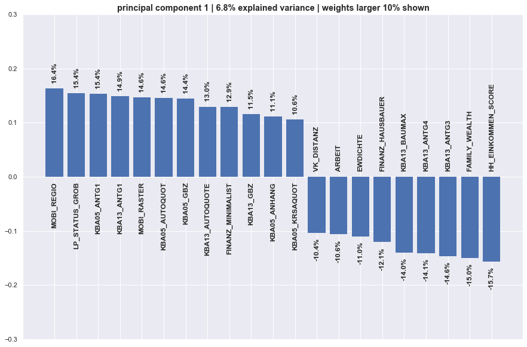

```python
# analysis of PC1
plot_pca_weights(df_pca_weights, 1)
```

**Analysis PC1**

- *high weights*
  - `MOBI_REGIO` = low mobility
  - `LP_STATUS_GROB` = houseowners, top earners
  - `KBA05_ANTG1` = high share of 1–2 family homes
  - `KBA13_ANTG1` = high share of 1–2 family homes
  - `MOBI_RASTER` = n.a.
  - `KBA05_AUTOQUOT` = high share of cars in neighborhood
  - `KBA05_GBZ` = multiple buildings in neighborhood
  - `KBA13_AUTOQUOT` = high share of cars in neighborhood
  - `FINANZ_MINIMALIST` = interested in finance
  - `KBA13_GBZ` = multiple buildings in neighborhood
  - `KBA05_ANHANG` = high share of trailers in neighborhood
  - `KBA05_KRSAQUOT` = above average share of cars in household
- *low weights*
  - `HH_EINKOMMEN_SCORE` = very high to highest incomes
  - `FAMILY_WEALTH` = wealthy households
  - `KBA13_ANTG3` = low share of 6-10 family households
  - `KBA13_ANTG4` = low share of 6-10 family households
  - `KBA13_BAUMAX` = mainly 1-2 family homes in neighborhood
  - `FINANZ_HAUSBAUER` = high focus on own house
  - `EWDICHTE` = low population density
  - `ARBEIT` = n.a.
  - `VK_DISTANZ` = n.a.

**PC1 measures household wealth**

- **high PC1 values = wealthy households**:
  - top earners, high incomes
  - live in 1–2 family houses
  - small communities with multiple buildings in neighborhood (due to 1–2 family houses)
  - own multiple cars; lots of cars in the neighborhood

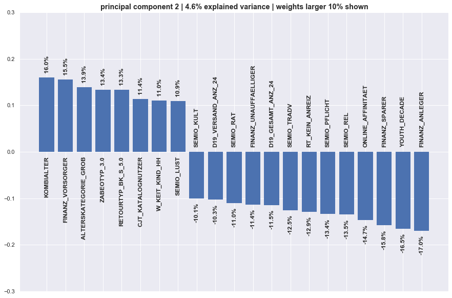

```python
# analysis of PC2
plot_pca_weights(df_pca_weights, 2)
```

**Analysis PC2**

- *high weights (selection)*
  - `KOMBIALTER` = n.a.
  - `FINANZ_VORSORGER` = not financially preparing
  - `ALTERSKATEGORIE_GROB` = older persons / uniformly distributed age
  - `ZABEOTYP_3` = fair supplied energy consumers
  - `RETOURTYP_BK_S_5` = minimal returners
  - `CJT_KATALOGBENUTZER` = n.a.
  - `W_KEIT_KIND_HH` = kids unlikely
  - `SEMIO_LUST` = low sensual affinity
- *low weights (selection)*
  - `FINANZ_ANLEGER` = investors
  - `YOUTH_DECADE` = born in 40ies, 50ies, or 60ies
  - `FINANZ_SPARER` = savers
  - `ONLINE_AFFINITAET` = low online affinity
  - `SEMIO_REL` = religious
  - `SEMIO_PFLICHT` = dutyful
  - `RT_KEIN_ANREIZ` = n.a.
  - `SEMIO_TRADV` = traditionally minded
  - `D19_GESAMT_ANZ_24` = low transaction activity in past 24 months
  - `FINANZ_UNAUFFAELLIGER` = financially unremarkable
  - `SEMIO_RAT` = rationally minded
  - `D19_VERSAND_ANZ_24` = low mail order activity
  - `SEMIO_KULT` = culturally minded

**PC2 measures age and mindset**

- **high PC2 values = traditionalists**:
  - older people
  - no kids
  - religious, dutyful; traditinally and culturally minded
  - low online activity
  - low number of transaction known
  - do not return online/mail orders

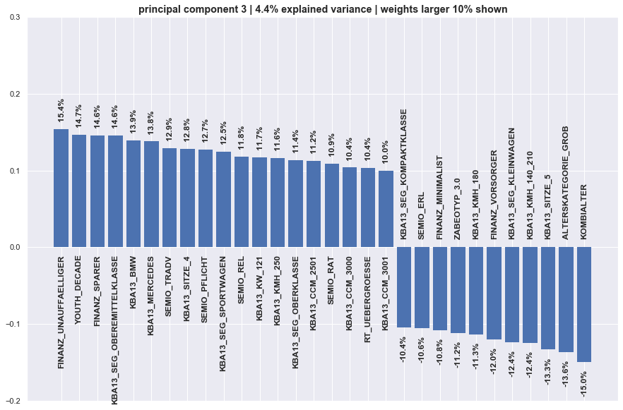

```python
# analysis of PC3
plot_pca_weights(df_pca_weights, 3)
```

**Analysis PC3**

- *high weights (selection)*
  - `FINANZ_UNAUFAELLIGER` = remarkable financial activity
  - `YOUTH_DECADE` = young
  - `FINANZ_SPARER` = not saving
  - `KBA13_SEG_OBERMITTELKLASSE` = high share of medium to top tier cars
  - `KBA13_BMW` = high share of BMW cars
  - `KBA13_MERCEDES` = high share of mercedes cars
  - `SEMIO_TRADV` = traditionally minded
  - `KBA13_SITZE4` = high share of cars with 4 sets
  - `SEMIO_PFLICHT` = dutyful
  - `KBA13_SEG_SPORTWAGEN` = high share of sports cars
  - `SEMIO_REL` = religious
  - `KBA13_KW_121` = high share of high-powered cars
  - `KBA13_KMH_250` = high share of cars with max speed 250
  - `KBA13_SEG_OBERKLASSE` = high share of top tier cars
  - `KBA13_CCM_2501` = high share of highly powered cars
  - `SEMIO_RAT` = traditionally minded
  - `KBA13_CCM_3000` = high share of highly powered cars
  - `RT_UEBERGROESSE` = n.a.
  - `KBA13_CCM_3000` = high share of highly powered cars
- *low weights (selection)*
  - `KOMBIALTER` = n.a.
  - `ALTERSKATEGORIE_GROB` = young (<30, 45)
  - `KBA13_SITZE_5` = low share of cars with 5 seats
  - `KBA13_KMH_140_210` = low share of cars with max speed 140-210
  - `KBA13_SEG_KLEINWAGEN` = low share of small cars
  - `FINANZ_VORSORGER` = financially prepared
  - `KBA13_KMH_180` = low share of cars with max speed 110–180
  - `ZABEOTYP_3` = fairly supplied energy consumers
  - `FINANZ_MINIMALIST` = financial minimalists
  - `SEMIO_ERL` = high affinity to events
  - `KBA13_SEG_KOMPAKTKLASSE` = low share of compact cars

**PC3 measures mindset about cars and oppinions**

- **high PC3 values = young car traditionalists**:
  - people between 31 and 45
  - high share of high-powered, high-value sports cars (BMW, Mercedes)
  - traditionally minded, dutyful, rational
  - high affinity towards events
  - financially prepared but not saving

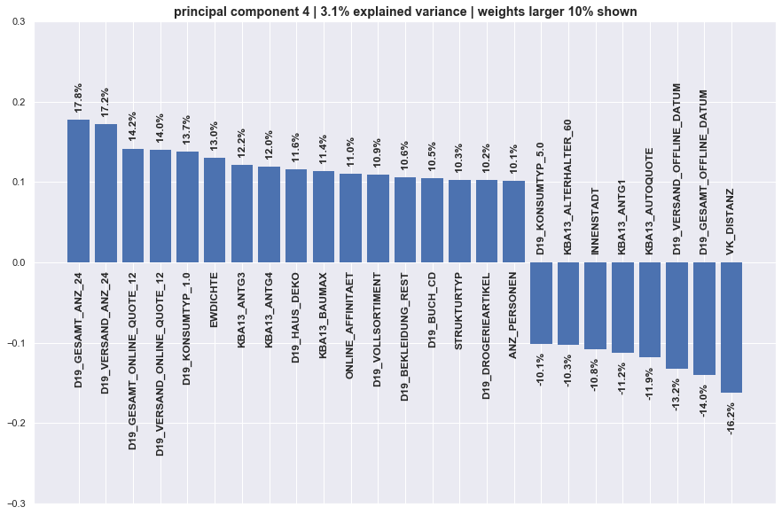

```python
# analysis of PC4
plot_pca_weights(df_pca_weights, 4)
```

**Analysis PC4**

- *high weights (selection)*
  - `D19_GESAMT_ANZ_24` = high transaction activity in last 2 years
  - `D19_VERSAND_ANZ_24` = high activity of mail orders in last 2 years
  - `D19_GESAMT_ONLINE_QUOTE12` = high share of online transaction
  - `D19_VERSAND_ONLINE_QUOTE12` = high share of online transactions for orders
  - `D19_KONSUMTYP_1` = universal consumption type
  - `EWDICHTE` = high population density
  - `KBA13_ANTG3` = high share of 6-10 family houses
  - `KBA13_ANTG4` = high share of 10+ family houses
  - `D19_HAUS_DEKO` = buyers of decoration in last 24 months
  - `KBA13_BAUMAX` = mainly 10+ family houses in neighborhood
  - `ONLINE_AFFINITAET` = high online affinity
  - `D19_VOLLSORTIMENT` = buyers of complete mail order sortiment in last 24 months
  - `D19_BEKLEIDUNG_REST` = buyers of clothing in last 24 months
  - `D19_VERSAND_ONLINE_QUOTE12` = high probablity of online transactions in last 12 months
  - `D19_BUCH_CD` = buyers of books and CDs last 24 months
  - `STRUKTURTYP` = n.a.
  - `D19_DROGERIEARTIKEL` = buyers of drugstore products in last 24 months
  - `ANZ_PERSONEN` = high number of persons in household
- *low weights (selection)*
  - `VK_DISTANZ` = n.a.
  - `D19_GESAMT_OFFLINE_DATUM` = high actitivty in offline orders
  - `D19_VERSAND_OFFLINE_DATUM` = high actitivty in offline mail orders
  - `KBA13_AUTOQUOTE` = low share of cars
  - `KBA13_ANTG1` = low share of 1-2 family homes
  - `INNENSTADT` = live in the city center
  - `KBA13_ALTERHALTER_60` = low share of old car owners
  - `D19_KONSUMTYP_5` = uniformed consumers

**PC4 measure shopping behavior**

- **high PC4 values = urban shoppers**:
  - live in urban environments with high populations density in 10+ family homes
  - online as well as mail orders
  - buy from broad spectrum of products

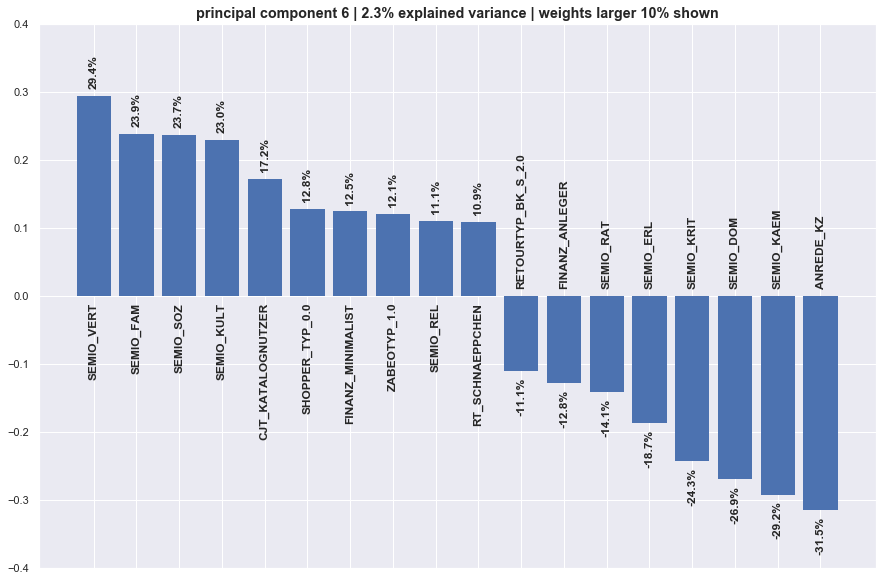

```python
# analysis of PC6
plot_pca_weights(df_pca_weights, 6)
```

**Analysis PC6**

- *high weights (selection)*
  - `SEMIO_VERT` = not dreamily
  - `SEMIO_FAM` = not family minded
  - `SEMIO_SOZ` = not socially minded
  - `SEMIO_KULT` = not culturally minded
  - `CJT_KATALOGBENUTZER` = n.a.
  - `SHOPPER_TYP_0` = externally supplied hedonists
  - `FINANZ_MINIMALIST` = high financial interest
  - `ZABEOTYP_1` = green energy consumers
  - `SEMIO_REL` = not relgious
  - `RT_SCHNAEPPCHEN` = n.a.
- *low weights (selection)*
  - `ANREDE_KZ` = male
  - `SEMIO_KAEM` = figthful
  - `SEMIO_DOM` = dominant
  - `SEMIO_KRIT` = critical
  - `SEMIO_RAT` = rational
  - `FINANZ_ANLEGER` = investors
  - `RETOURTYP_BK_S_2` = not demanding crazy retouerns

**PC6 measures sex and attitudes**

- **high PC6 values = competitive male investors**:
  - dominant, competitive, cricital, rational males
  - financially interested; investors

### 2.2 Clustering analysis

```python
# create dataframe of pca
df_pc = pd.DataFrame(data_pca_n,
                     columns=['PC{}'.format(i) for i in range(1, n_components+1)],
                     index=df_cleaned.index)
```

```python
# apply KMeans clustering on general demographic data
from sklearn.cluster import MiniBatchKMeans

clusters = range(2,21)
scores = np.zeros_like(clusters)

# Over a number of different cluster counts...
for i, clst in enumerate(clusters):

    # run k-means clustering on the data and...
    print('Fitting KMeans with %i clusters...' % clst)
    kmeans = MiniBatchKMeans(n_clusters=clst, random_state=10, batch_size=1000, max_iter=1000, n_init=10)
    kmeans.fit(data_pca_n)

    # compute the average within-cluster distances.
    scores[i] = kmeans.score(data_pca_n)
```

```
Fitting KMeans with 2 clusters...
Fitting KMeans with 3 clusters...
Fitting KMeans with 4 clusters...
Fitting KMeans with 5 clusters...
Fitting KMeans with 6 clusters...
Fitting KMeans with 7 clusters...
Fitting KMeans with 8 clusters...
Fitting KMeans with 9 clusters...
Fitting KMeans with 10 clusters...
Fitting KMeans with 11 clusters...
Fitting KMeans with 12 clusters...
Fitting KMeans with 13 clusters...
Fitting KMeans with 14 clusters...
Fitting KMeans with 15 clusters...
Fitting KMeans with 16 clusters...
Fitting KMeans with 17 clusters...
Fitting KMeans with 18 clusters...
Fitting KMeans with 19 clusters...
Fitting KMeans with 20 clusters...
```

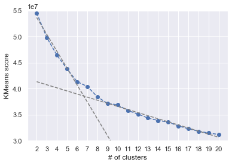

```python
# calculate relative change with increasing number of clusers
relative_change = -1.0*(scores[1:] - scores[0:-1])/scores[0:-1]

p_low = np.polyfit(clusters[0:5], -1.0*scores[0:5], 1)
p_high = np.polyfit(clusters[-13:], -1.0*scores[-13:], 1)

# plot score vs. number of clusters
plt.figure()
plt.plot(clusters, -1.0*scores, 'bo--')
plt.plot(clusters, np.polyval(p_low, clusters), '--', color='0.5')
plt.plot(clusters, np.polyval(p_high, clusters), '--', color='0.5')
plt.ylim(3.0e+07, 5.5e+07)
plt.xticks(clusters)
plt.xlabel('# of clusters')
plt.ylabel('KMeans score')
```

```python
# perform clustering using 8 clusters
kmeans = MiniBatchKMeans(n_clusters=8, random_state=10, batch_size=1000, max_iter=1000, n_init=10)
kmeans.fit(data_pca_n)
cluster_labels = kmeans.predict(data_pca_n)
```

```python
# add cluster labels to dataframe (encoded in PCs)
df_pc['CLUSTER_LABEL'] = cluster_labels+1
```

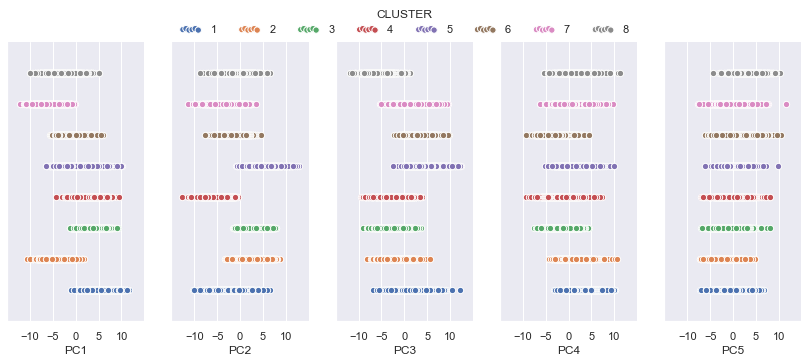

```python
g = sns.PairGrid(df_pc.iloc[::100],
                 x_vars=['PC{}'.format(i) for i in range(1,6)], y_vars=['CLUSTER_LABEL'], hue='CLUSTER_LABEL')

g.fig.set_size_inches(12,6)

g = g.map(plt.scatter, linewidths=1.0, edgecolor='w', s=40)
g.axes[0,0].set_ylim(0, 9)
g.axes[0,0].set_yticks([])
g.axes[0,0].set_ylabel('')

for i in range(5):
    g.axes[0,i].set_xlim(-15, 15)
    g.axes[0,i].set_xticks([-10, -5, 0, 5, 10])

handles = g._legend_data.values()
labels = g._legend_data.keys()
g.fig.legend(handles=handles, labels=labels, title='CLUSTER', ncol=8,
             frameon=False, scatterpoints=6, loc='upper center')
```

```python
# load customers data
customers = pd.read_csv('./arvato_data/Udacity_CUSTOMERS_052018.csv', sep=';')
```

```python
# get shape of customers dataset
customers.shape
```

```
(191652, 369)
```

```python
# get shape of the population dataset
azdias.shape
```

```
(891221, 366)
```

**Observation:** the customers dataset has three more features that are not in the population dataset. These will be dropped from the customer dataset before pre-processing of the data.

```python
# find difference between customer and population features
customer_columns = list(set(customers.columns.to_list()) - set(azdias.columns.to_list()))
print(customer_columns)
```

```
['CUSTOMER_GROUP', 'ONLINE_PURCHASE', 'PRODUCT_GROUP']
```

```python
# drop additional customer columns before pre-processing
customers.drop(customer_columns, axis=1, inplace=True)
```

```python
# apply preprocessing, feature transformation, and clustering from the general
# demographics onto the customer data, obtaining cluster predictions for the
# customer demographics data.

n_customer = customers.shape[0]

# data cleaning
customers_cleaned = clean_data(customers, missing_list)

n_customer_cleaned = customers_cleaned.shape[0]
n_customer_missing = n_customer - n_customer_cleaned

print('%i (%.1f%%) incomplete rows in customer data after cleaning' % (n_customer_missing,
                                                                       n_customer_missing/n_customer*100.0))
# feature scaling
# check for missing values
print(customers_cleaned.isnull().sum().sum())
customers_std = scaler.transform(customers_cleaned)

# apply PCA
customers_pca_n = pca_n.transform(customers_std)

# apply clustering
customers_labels = kmeans.predict(customers_pca_n)
```

```
# complete row fraction:   68.2%
# incomplete row fraction: 31.8%
60885 (31.8%) incomplete rows in customer data after cleaning
0
```

```python
# create dataframe of customers pc
customer_pc = pd.DataFrame(customers_pca_n,
                           columns=['PC{}'.format(i) for i in range(1, n_components+1)],
                           index=customers_cleaned.index)


# add cluster labels to dataframe (encoded in PCs)
customer_pc['CLUSTER_LABEL'] = customers_labels+1
```

```python
# create dataframe to compare the proportion of clusters in the population and customer dataset
df_compare = pd.DataFrame(index=range(1,17), columns=['CLUSTER', 'ABS_COUNT', 'REL_COUNT', 'DATASET'])
df_compare['CLUSTER'].iloc[0:8] = range(1,9)
df_compare['CLUSTER'].iloc[8:] = range(1,9)

df_compare['DATASET'].iloc[0:8] = 'population'
df_compare['DATASET'].iloc[8:] = 'customers'

df_compare['ABS_COUNT'].iloc[0:8] = df_pc['CLUSTER_LABEL'].value_counts(sort=False).values
df_compare['ABS_COUNT'].iloc[8:] = customer_pc['CLUSTER_LABEL'].value_counts(sort=False).values

df_compare['REL_COUNT'].iloc[0:8] = df_compare['ABS_COUNT'].iloc[0:8].values/df_pc.shape[0]
df_compare['REL_COUNT'].iloc[8:] = df_compare['ABS_COUNT'].iloc[8:].values/customer_pc.shape[0]
```

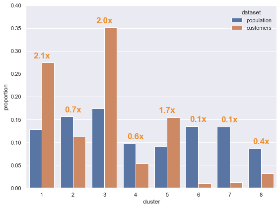

```python
fig = plt.figure(figsize=(8,6))
sns.barplot(data=df_compare, x='CLUSTER', y='REL_COUNT', hue='DATASET')
for i in range(8):
    plt.text(i, max(df_compare['REL_COUNT'].iloc[i], df_compare['REL_COUNT'].iloc[i+8])+0.01,
             '{:.1f}x'.format(df_compare['REL_COUNT'].iloc[i+8]/df_compare['REL_COUNT'].iloc[i]),
             weight='bold', fontsize='x-large', ha='center', color='#F28E2B')

plt.ylim(0.0, 0.4)
plt.xlabel('cluster')
plt.ylabel('proportion')
plt.legend(frameon=False, loc=0, title='dataset')
plt.tight_layout()
fig.savefig('plots/cluster_proportions.png', dpi=300.0)
```

**Observations**

- clusters 1, 3, and 5 are overrepresented in the customer dataset
- individuals from these clusters are likely to respond to an advertisment campaign
- clusters 6, 7, and 8 are underrepresented in the customer dataset

```python
# analyze centroids of over/underrepresented clusters
df_cluster_centers = pd.DataFrame(kmeans.cluster_centers_,
                                  columns=['PC{}'.format(i) for i in range(1,11)])

# add cluster labels
df_cluster_centers['CLUSTER_LABEL'] = df_cluster_centers.index+1
```

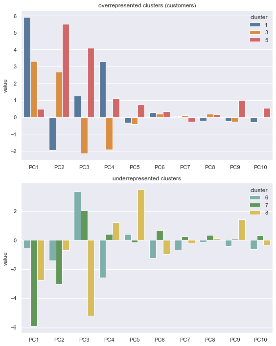

```python
idx_over = df_cluster_centers.melt('CLUSTER_LABEL')['CLUSTER_LABEL'].isin([1, 3, 5])
idx_under = df_cluster_centers.melt('CLUSTER_LABEL')['CLUSTER_LABEL'].isin([6, 7, 8])

fig = plt.figure(figsize=(8,10))
plt.subplot(2, 1, 1)
sns.barplot(data=df_cluster_centers.melt('CLUSTER_LABEL')[idx_over],
            x='variable', y='value', hue='CLUSTER_LABEL', palette=tableau10)
plt.legend(loc=0, title='cluster', frameon=False)
plt.xlabel('')
plt.title('overrepresented clusters (customers)')

plt.subplot(2, 1, 2)
sns.barplot(data=df_cluster_centers.melt('CLUSTER_LABEL')[idx_under],
            x='variable', y='value', hue='CLUSTER_LABEL', palette=tableau10[3:])
plt.legend(loc=0, title='cluster', frameon=False)
plt.xlabel('')
plt.title('underrepresented clusters')

plt.tight_layout()
fig.savefig('plots/cluster_centroids.png', dpi=300.0)
```

**Observations:**

- **cluster 1 = customers**
  - very high PC1 = wealthy households
  - low PC2
  - high PC4 = online shoppers, broad product spectrum
- **cluster 3 = customers**
  - high PC1 = wealthy households
  - high PC2 = traditionalists, old persons
  - low PC3
  - low PC4 = offline shoppers
- **cluster 5 = maybe customers**
  - very high PC2
  - high PC3
- **cluster 6 = no customers**
  - high PC3
  - low PC4
- **cluster 7 = no customers**
  - very low PC1
  - low PC2
  - high PC3
- **cluster 8 = no customers**
  - low PC1
  - very low PC3
  - high PC5

## Part 3: Supervised Learning Model

Now that you've found which parts of the population are more likely to be customers of the mail-order company, it's time to build a prediction model. Each of the rows in the "MAILOUT" data files represents an individual that was targeted for a mailout campaign. Ideally, we should be able to use the demographic information from each individual to decide whether or not it will be worth it to include that person in the campaign.

The "MAILOUT" data has been split into two approximately equal parts, each with almost 43 000 data rows. In this part, you can verify your model with the "TRAIN" partition, which includes a column, "RESPONSE", that states whether or not a person became a customer of the company following the campaign. In the next part, you'll need to create predictions on the "TEST" partition, where the "RESPONSE" column has been withheld.

### 3.1 Data preparation

```python
# read training data
mailout_train = pd.read_csv('./arvato_data/Udacity_MAILOUT_052018_TRAIN.csv', sep=';')
```

```python
# get labels (RESPONSE)
mailout_labels = mailout_train['RESPONSE']

# drop RESPONSE column from the original dataframe
mailout_train.drop(['RESPONSE'], axis=1, inplace=True)
mailout_train.shape
```

```
(42962, 366)
```

```python
# clean the training data using the developed cleaning function; do not use imputation though
mailout_data_cleaned = clean_data(mailout_train, missing_list,
                                  remove_lines=True, lines_threshold=9, impute=False)
```

```
# complete row fraction:   77.0%
# incomplete row fraction: 23.0%
```

```python
# check shape of the data
mailout_data_cleaned.shape
```

```
(33067, 318)
```

```python
# check missing values
mailout_data_cleaned.isna().sum().sum()
```

```
10654
```

```python
# check distribution of positive responses in complete training set
mailout_labels.value_counts(normalize=True)
```

```
0    0.987617
1    0.012383
Name: RESPONSE, dtype: float64
```

```python
# check distribution of positive responses in cleaned training set
mailout_labels.loc[mailout_data_cleaned.index].value_counts(normalize=True)
```

```
0    0.98754
1    0.01246
Name: RESPONSE, dtype: float64
```

**Observation**:

- the cleaning function developed for the clustering analysis was applied to the training data, however, without imputing missing values
- the missing values will be imputed based on the medians in the training dataset
- the fraction of positive response in the cleaned dataset did not change due to the removal of rows with more than 9 missing values

### 3.2 Algorithm screening

```python
def screen_classifier(clf, cv, X, y, train_sizes, scoring='roc_auc', clf_name='', plot=True):
    """
    Create learning curve for a given classifier.

    INPUTS
    ------
    clf
        classifier
    cv
        cross-validator

    X : ndarray
        feature data

    y : ndarryy
        labels

    train_sizes : list
        fractions of training set to be used

    scoring : str
        scoring metric

    plot : boolean
        switch to enable plot of learning curve

    OUTPUTS
    -------
    final_score_mean : float
        mean final validation score using complete training set

    final_score_std : float
        std final validation score using complete training set
    """

    # calculate learing curve
    scores = learning_curve(clf_pipe, X, y, cv=cv, scoring=scoring,
                        train_sizes=train_sizes, shuffle=True, random_state=10, n_jobs=-1, verbose=1)

    # assign training sizes and training and validation scores
    train_sizes, train_scores, validation_scores = scores

    # calculate mean and std of scores
    train_scores_mean = np.mean(train_scores, axis=1)
    train_scores_std = np.std(train_scores, axis=1)
    validation_scores_mean = np.mean(validation_scores, axis=1)
    validation_scores_std = np.std(validation_scores, axis=1)

    final_score_mean = validation_scores_mean[-1]
    final_score_std = validation_scores_std[-1]

    # report scores
    print(clf_name + ': ROC-AUC score = {:.4f} ({:.4f})'.format(final_score_mean, final_score_std))

    # plot learning curve
    if plot == True:
        fig = plt.figure(figsize=(8,6))
        plt.plot(train_sizes, train_scores_mean, 'o--', label='training')
        plt.fill_between(train_sizes, train_scores_mean-train_scores_std, train_scores_mean+train_scores_std,
                         alpha=0.15)
        plt.plot(train_sizes, validation_scores_mean, 'o--', label='validation')
        plt.fill_between(train_sizes, validation_scores_mean-train_scores_std, validation_scores_mean+train_scores_std,
                         alpha=0.15)
        plt.ylim(0.45, 1.05)
        plt.xlabel('training samples')
        plt.ylabel('ROC-AUC score')
        plt.legend(loc=0)
        plt.title(clf_name + ' (ROC-AUC = {:.4f}+-{:.4f})'.format(final_score_mean, final_score_std))
        fig.tight_layout()

    return (final_score_mean, final_score_std)
```

```python
# assign features and labels
X = mailout_data_cleaned.values
y = mailout_labels.loc[mailout_data_cleaned.index].values
```

```python
# split data in training and test set
# save 10% of data for last test before making final prediction
X_train, X_test, y_train, y_test = train_test_split(X, y, test_size=0.1, stratify=y, random_state=10)
```

```python
# setup cross-validator
cv = StratifiedShuffleSplit(n_splits=5, test_size=0.2, random_state=10)
```

```python
# build classifier pipeline
pre_pipe = Pipeline(steps=[('impute', SimpleImputer(strategy='median')),
                           ('scale', StandardScaler())])
```

```
[learning_curve] Training set sizes: [ 2380  7142 11904 17856 23808]
```

```
[Parallel(n_jobs=-1)]: Using backend LokyBackend with 4 concurrent workers.
[Parallel(n_jobs=-1)]: Done  25 out of  25 | elapsed:  3.5min finished
```

```
NN: ROC-AUC score = 0.6622 (0.0249)
[learning_curve] Training set sizes: [ 2380  7142 11904 17856 23808]
```

```
[Parallel(n_jobs=-1)]: Using backend LokyBackend with 4 concurrent workers.
[Parallel(n_jobs=-1)]: Done  25 out of  25 | elapsed:  2.6min finished
```

```
AdaBoost: ROC-AUC score = 0.7641 (0.0238)
[learning_curve] Training set sizes: [ 2380  7142 11904 17856 23808]
```

```
[Parallel(n_jobs=-1)]: Using backend LokyBackend with 4 concurrent workers.
[Parallel(n_jobs=-1)]: Done  25 out of  25 | elapsed: 10.5min finished
```

```
GradientBoost: ROC-AUC score = 0.7794 (0.0304)
```

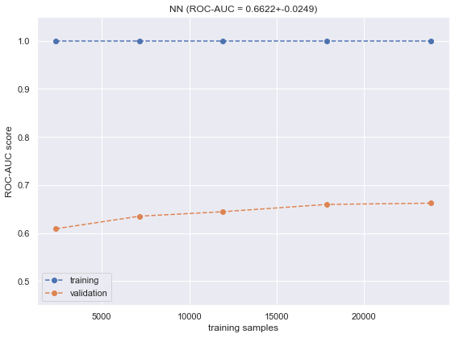

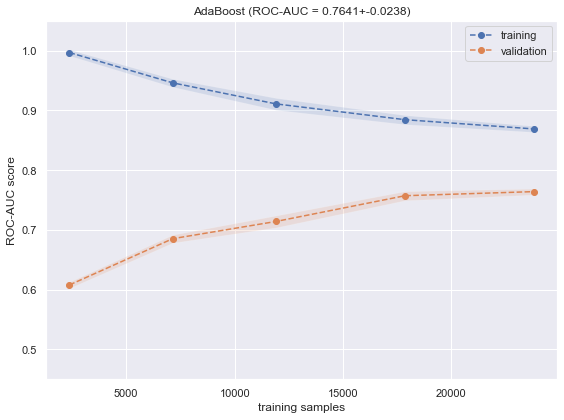

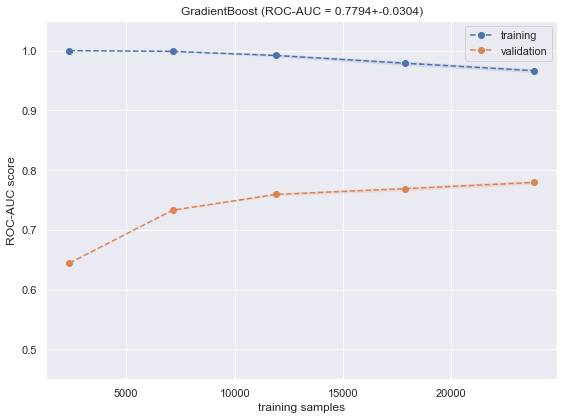

```python
# list of classifier candidates
classifiers = [{'name': 'NN', 'clf': MLPClassifier()},
               {'name': 'AdaBoost', 'clf': AdaBoostClassifier()},
               {'name': 'GradientBoost', 'clf': GradientBoostingClassifier()}]

# list of scores
scores = []

# screen classifiers
train_sizes = [0.1, 0.3, 0.5, 0.75, 1.0]

for clf in classifiers:
    # create classifier pipeline
    clf_pipe = Pipeline(steps=[('prepare', pre_pipe), ('clf_'+clf['name'], clf['clf'])])

    # create learning curve
    final_score_mean, final_score_std = screen_classifier(clf_pipe, cv, X_train, y_train, train_sizes,
                                                          clf_name=clf['name'])

    # append final score to list
    scores.append(final_score_mean)
```

**Analysis:**

**Conclusion:** continue with **GradientBoost** classifier as it has the highest out-of-the-box score and seems to capture the features well.

### 3.2 Improve predictions: using more training data

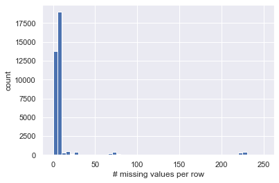

```python
# plot distribution of missing values per row in original training set
plt.hist(mailout_train.isna().sum(axis=1).values, bins=range(0,255,5))
plt.xlabel('# missing values per row')
plt.ylabel('count')
```

**Observation:** using more data is not possible as only few more rows are available; these rows need a high fraction of imputation

### 3.3 Improve predictions: reduce feature space

Another option to improve the model performance is to reduce the feature space. Therefore, two options are explored:

#### 3.3.1 Use features from principal component 1

```python
# implement function to get most relevant features from principal components
def get_principal_features(df, components, threshold=0.1):

    # initialize lists of features and indices
    features_total = []
    feature_indices_total = []

    # loop over principal components
    for component in components:

        # extract weights
        weights = df.iloc[component-1, 0:-1].values
        features = np.array((df.columns[0:-1]))

        # sort values and features by weight
        idx = np.argsort(-1.0*weights)
        weights_sorted = weights[idx]
        features_sorted = features[idx]


        # reduce to features with weights higher +-0.1
        weights_pos = np.trim_zeros(np.where(weights_sorted >= threshold, weights_sorted, 0.0))
        weights_neg = np.trim_zeros(np.where(weights_sorted <= -1.0*threshold, weights_sorted, 0.0))
        weights_main = np.hstack((weights_pos, weights_neg))

        # get indices of features above/below threshold
        n_pos = len(weights_pos)
        n_neg = len(weights_neg)

        # build list of principal features
        features_total.extend(np.hstack((features_sorted[0:n_pos], features_sorted[-n_neg:])).tolist())

    # remove duplicate features
    features_total = list(set(features_total))

    # get indices of all principal features
    for i in range(len(features_total)):
        feature_indices_total.append(df.columns.get_loc(features_total[i]))

    # convert index list to array
    features_idx = np.array(feature_indices_total)

    return (features_total, features_idx)
```

```python
# get features from principal component 1 with weights higher/lower 0.1
features_main, features_idx = get_principal_features(df_pca_weights, [1], threshold=0.1)
print(len(features_main))
```

```
21
```

```python
# select most relevant features in training set
X_train_reduced = X_train[:, features_idx]
```

```
[learning_curve] Training set sizes: [ 2380  7142 11904 17856 23808]
```

```
[Parallel(n_jobs=-1)]: Using backend LokyBackend with 4 concurrent workers.
```

```
GradientBoost: ROC-AUC score = 0.5562 (0.0228)
```

```
[Parallel(n_jobs=-1)]: Done  25 out of  25 | elapsed:   34.6s finished
```

```
(0.5562461491774183, 0.02275204753401595)
```

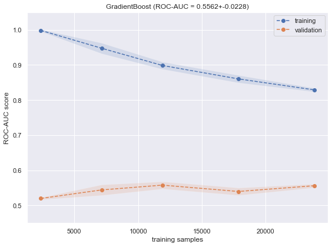

```python
# fit classifier with reduced feature space

# create classifier pipeline
clf_pipe = Pipeline(steps=[('prepare', pre_pipe), ('clf_GradientBoost', GradientBoostingClassifier())])

# assess performance of GradientBoost classifier on reduced feature set
screen_classifier(clf_pipe, cv, X_train_reduced, y_train, train_sizes, clf_name='GradientBoost')
```

**Observation:** the validaton score remains constant so the model is not able to learn well from the data (high bias); more features are required; I will include features with weights higher/lower 5% to PC1

```python
# get features from principal component 1 with weights higher/lower 0.05
features_main, features_idx = get_principal_features(df_pca_weights, [1], threshold=0.05)
print(len(features_main))
```

```
108
```

```python
# select most relevant features in training set
X_train_reduced = X_train[:, features_idx]
```

```
[learning_curve] Training set sizes: [ 2380  7142 11904 17856 23808]
```

```
[Parallel(n_jobs=-1)]: Using backend LokyBackend with 4 concurrent workers.
```

```
GradientBoost: ROC-AUC score = 0.7758 (0.0238)
```

```
[Parallel(n_jobs=-1)]: Done  25 out of  25 | elapsed:  3.4min finished
```

```
(0.775810856790782, 0.023758567643131126)
```

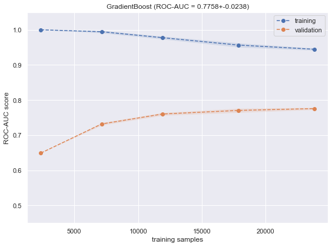

```python
# fit classifier with reduced feature space

# create classifier pipeline
clf_pipe = Pipeline(steps=[('prepare', pre_pipe), ('clf_GradientBoost', GradientBoostingClassifier())])

# assess performance of GradientBoost classifier on reduced feature set
screen_classifier(clf_pipe, cv, X_train_reduced, y_train, train_sizes, clf_name='GradientBoost')
```

```python
# get features from principal component 1 with weights higher/lower 0.05
features_main, features_idx = get_principal_features(df_pca_weights, [1, 2, 4], threshold=0.1)
print(len(features_main))
```

```
57
```

```python
# select most relevant features in training set
X_train_reduced = X_train[:, features_idx]
```

```
[learning_curve] Training set sizes: [ 2380  7142 11904 17856 23808]
```

```
[Parallel(n_jobs=-1)]: Using backend LokyBackend with 4 concurrent workers.
```

```
GradientBoost: ROC-AUC score = 0.5860 (0.0129)
```

```
[Parallel(n_jobs=-1)]: Done  25 out of  25 | elapsed:  1.4min finished
```

```
(0.5860184103804384, 0.012947057839546137)
```

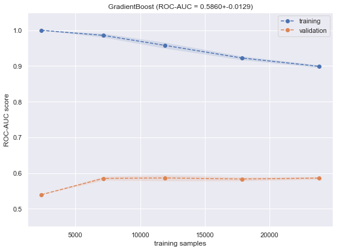

```python
# fit classifier with reduced feature space

# create classifier pipeline
clf_pipe = Pipeline(steps=[('prepare', pre_pipe), ('clf_GradientBoost', GradientBoostingClassifier())])

# assess performance of GradientBoost classifier on reduced feature set
screen_classifier(clf_pipe, cv, X_train_reduced, y_train, train_sizes, clf_name='GradientBoost')
```

**Observation:**

- adding more features from PC1 improves the model performance
  - the ROC-AUC score, however, is not higher than in the initial screening
- choosing the main features (more/less than 10% weigth) from PCs 1, 2, and 4 which separated the customer from the non-customers gives a ROC-AUC score of only 0.59
- a major drawback in selecting features from the principal component is that the PCA does not include the training labels; therefore, feature selection with a tree classifier will be conducted